# Entrega II Individual

Entrega SEMMA

Roberto Bonilla Ibarra (Universidad Complutense de Madrid)  
2022-12-27

# Objetivo

## Paquetes necesarios

Necesitaremos los siguientes paquetes

- **Análisis exploratorio numérico**: paquete `{skimr}`
- **Depuración y preprocesamiento**: paquete `{tidyverse}`
- **Modelización**: paquete `{tidymodels}` para modelos
- **Detección de outliers**: paquete `{outliers}`

```r
# Borramos
rm(list = ls())

# Paquetes
library(skimr) # resumen numérico
library(tidymodels) # depuración datos
library(tidyverse) # modelos
library(outliers) # outliers
library(timeDate) # fechas
library(ggthemes) # tema para graficar
```

# Datos

Vamos ir a un **ejemplo real**, haciendo uso de un **dataset de adultos con distintas variables socioeconómicas.**

```r
adultos <- read_csv(file = "./datos/adults.csv")
```

Los datos forman parte de un **censo poblacional relacionado a la percepción económica** elaborado por US Census Bureau con 32,561 registros.

📚 **Detalle de variables**: http://www.cs.toronto.edu/~delve/data/adult/adultDetail.html1

## Análisis exploratorio inicial (numérico)

Antes de tomar ninguna decisión con los datos lo primero que deberíamos hacer es **echar un vistazo numérico** a cómo se comportan las variables. Dado que vamos a clasificar, lo primero que deberíamos observar es como se distribuyen los niveles de nuestra variable objetivo.

### Variables

Lo primero es conocer las variables

```r
glimpse(adultos)
```

```
Rows: 32,561
Columns: 15
$ age            <dbl> 39, 50, 38, 53, 28, 37, 49, 52, 31, 42, 37, 3…
$ workclass      <chr> "State-gov,", "Self-emp-not-inc,", "Private,"…
$ fnlwgt         <dbl> 77516, 83311, 215646, 234721, 338409, 284582,…
$ education      <chr> "Bachelors,", "Bachelors,", "HS-grad,", "11th…
$ education_num  <dbl> 13, 13, 9, 7, 13, 14, 5, 9, 14, 13, 10, 13, 1…
$ marital_status <chr> "Never-married,", "Married-civ-spouse,", "Div…
$ occupation     <chr> "Adm-clerical,", "Exec-managerial,", "Handler…
$ relationship   <chr> "Not-in-family,", "Husband,", "Not-in-family,…
$ race           <chr> "White,", "White,", "White,", "Black,", "Blac…
$ sex            <chr> "Male,", "Male,", "Male,", "Male,", "Female,"…
$ capital_gain   <chr> "2174,", "0,", "0,", "0,", "0,", "0,", "0,", …
$ capital_loss   <chr> "0,", "0,", "0,", "0,", "0,", "0,", "0,", "0,…
$ hours_per_week <dbl> 40, 13, 40, 40, 40, 40, 16, 45, 50, 40, 80, 4…
$ native_country <chr> "United-States,", "United-States,", "United-S…
$ over_50k       <chr> "<=50K", "<=50K", "<=50K", "<=50K", "<=50K", …
```

- `age`: Edad de los individuos
- `workclass`: Tipo de trabajo de cada individuo
- `fnlwgt`: Número de personas con la misma edad y raza.
- `education,education_num`: Nivel de educación máximo
- `marital_status`: Situación sentimental del individuo.
- `occupation`: A lo que se dedica el individuo
- `relationship`: Cuál es la relación que tiene con su familia.
- `race`: Raza del individuo
- `sex`: Sexo del individuo
- `capital_gain`: Capital percibido
- `capital_loss`: Capital perdido
- `hours_per_week`: Horas de trabajo semanales
- `native_country`: País de origen
- `over_50k`: Si el individuo percibe un ingreso mayor a 50 mil dólares anuales o menor o igual a este.

Además con la función `skim()` del paquete `{skimr}` podemos **extraer algunas estadísticas básicas** de nuestros datos.

```r
# Resumen numérico
adultos |> skim()
```

Table 1: Data summary

| Name | adultos |
| --- | --- |
| Number of rows | 32561 |
| Number of columns | 15 |
| _______________________ |  |
| Column type frequency: |  |
| character | 11 |
| numeric | 4 |
| ________________________ |  |
| Group variables | None |

**Variable type: character**

| skim_variable | n_missing | complete_rate | min | max | empty | n_unique | whitespace |
| --- | --- | --- | --- | --- | --- | --- | --- |
| workclass | 0 | 1 | 2 | 17 | 0 | 9 | 0 |
| education | 0 | 1 | 4 | 13 | 0 | 16 | 0 |
| marital_status | 0 | 1 | 8 | 22 | 0 | 7 | 0 |
| occupation | 0 | 1 | 2 | 18 | 0 | 15 | 0 |
| relationship | 0 | 1 | 5 | 15 | 0 | 6 | 0 |
| race | 0 | 1 | 6 | 19 | 0 | 5 | 0 |
| sex | 0 | 1 | 5 | 7 | 0 | 2 | 0 |
| capital_gain | 0 | 1 | 2 | 6 | 0 | 119 | 0 |
| capital_loss | 0 | 1 | 2 | 5 | 0 | 92 | 0 |
| native_country | 0 | 1 | 2 | 27 | 0 | 42 | 0 |
| over_50k | 0 | 1 | 4 | 5 | 0 | 2 | 0 |

**Variable type: numeric**

| skim_variable | n_missing | complete_rate | mean | sd | p0 | p25 | p50 | p75 | p100 | hist |
| --- | --- | --- | --- | --- | --- | --- | --- | --- | --- | --- |
| age | 0 | 1 | 38.58 | 13.64 | 17 | 28 | 37 | 48 | 90 | ▇▇▅▂▁ |
| fnlwgt | 0 | 1 | 189778.37 | 105549.98 | 12285 | 117827 | 178356 | 237051 | 1484705 | ▇▁▁▁▁ |
| education_num | 0 | 1 | 10.08 | 2.57 | 1 | 9 | 10 | 12 | 16 | ▁▁▇▃▁ |
| hours_per_week | 0 | 1 | 40.44 | 12.35 | 1 | 40 | 40 | 45 | 99 | ▁▇▃▁▁ |

Veamos los tipos de dato de las variables:

```r
sapply(adultos, class)
```

```
           age      workclass         fnlwgt      education
     "numeric"    "character"      "numeric"    "character"
 education_num marital_status     occupation   relationship
     "numeric"    "character"    "character"    "character"
          race            sex   capital_gain   capital_loss
   "character"    "character"    "character"    "character"
hours_per_week native_country       over_50k
     "numeric"    "character"    "character"
```

Podemos ver que tenemos que cambiar el tipo de dato de la variable capital loss y capital gain, veamos su distribución,

**Capital Gain**

```r
adultos |>
  count(capital_gain) |>
  mutate(porc = 100*n/sum(n))
```

```
# A tibble: 119 × 3
   capital_gain     n     porc
   <chr>        <int>    <dbl>
 1 0,           29849 91.7
 2 10520,          43  0.132
 3 1055,           25  0.0768
 4 10566,           6  0.0184
 5 10605,          12  0.0369
 6 1086,            4  0.0123
 7 1111,            1  0.00307
 8 114,             6  0.0184
 9 1151,            8  0.0246
10 11678,           2  0.00614
# … with 109 more rows
```

**Capital Loss**

```r
adultos |>
  count(capital_loss) |>
  mutate(porc = 100*n/sum(n))
```

```
# A tibble: 92 × 3
   capital_loss     n     porc
   <chr>        <int>    <dbl>
 1 0,           31042 95.3
 2 1092,            7  0.0215
 3 1138,            2  0.00614
 4 1258,            4  0.0123
 5 1340,            7  0.0215
 6 1380,            7  0.0215
 7 1408,           21  0.0645
 8 1411,            1  0.00307
 9 1485,           51  0.157
10 1504,           18  0.0553
# … with 82 more rows
```

Hemos visto que son variables continuas, por la tanto las convertiremos en numéricas:

```r
adultos$capital_gain <- as.numeric(str_replace_all(adultos$capital_gain,',',''))
adultos$capital_loss <- as.numeric(str_replace_all(adultos$capital_loss,',',''))
```

### Balance la variable objetivo

El objetivo será **predecir si un adulto está destinado a recibir un ingreso mayor a 50 mil dólares anuales o menor o igual a este**, por lo que la variable `over_50k` será nuestra variable objetivo. Primer paso: conocer cómo se **distribuyen los niveles de la objetivo** (es binaria)

```r
adultos |>
  count(over_50k) |>
  mutate(porc = 100*n/sum(n))
```

```
# A tibble: 2 × 3
  over_50k     n  porc
  <chr>    <int> <dbl>
1 <=50K    24720  75.9
2 >50K      7841  24.1
```

Podemos ver que nuestra variable objetivo está desbalanceada hacia las personas con un ingreso menor o igual a 50 mil dólares.

# Análisis Exploratorio Visual

Antes de poder tomar decisiones en cómo transformar nuestros datos es importante poder hacer un análisis detallado visual de nuestros datos y conocer cómo interactúan con la variable objetivo:

Para esto usaremos el tema del economist del paquete ggplothemes

## Distribución visual variable objetivo

La Variable Objetivo se encuentre desbalanceda, teniendo un 75% de casos donde las personas ganan menos que 50 mil dólares al año.

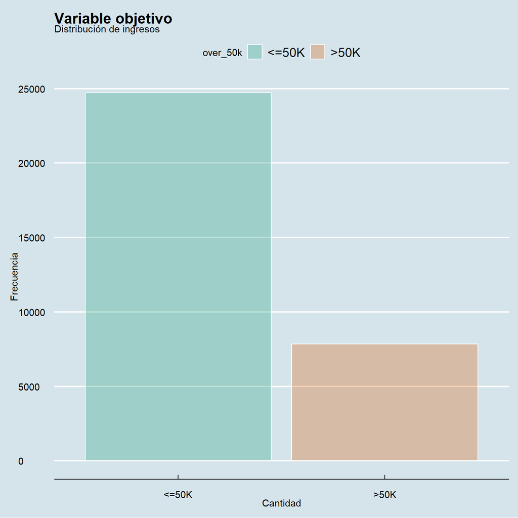

```r
ggplot(adultos, aes(x = over_50k, fill = over_50k)) +
  geom_bar(color = "white", alpha = 0.3) +
  scale_fill_brewer(palette = "Dark2") +
  labs(title = "Variable objetivo",
       subtitle = "Distribución de ingresos",
       x = "Cantidad", y = "Frecuencia") +
  theme_economist()
```

## Distribución visual variables continuas

### Variable Edad

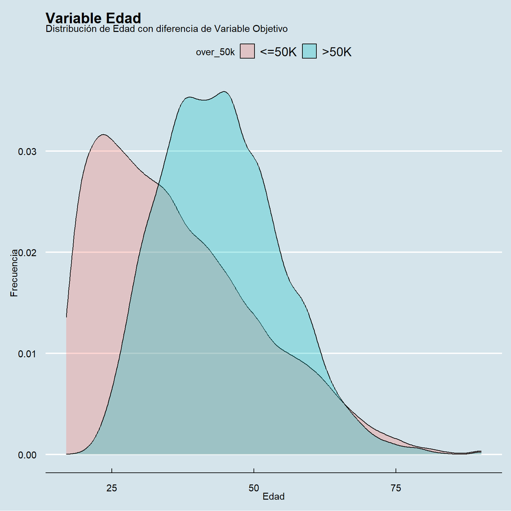

```r
ggplot(adultos, aes(x = age, fill = over_50k)) +
    geom_density(alpha = .3) +
    labs(title = "Variable Edad",
       subtitle = "Distribución de Edad con diferencia de Variable Objetivo",
       x = "Edad", y = "Frecuencia") +
  theme_economist()
```

Podemos ver que las personas que ganan más de 50 mil dólares al año tienden a ser de mayor edad en comparación con los que hacen menos o igual a 50 mil dólares al año, también podemos ver que la mayoría están entre 30 y 55 años.

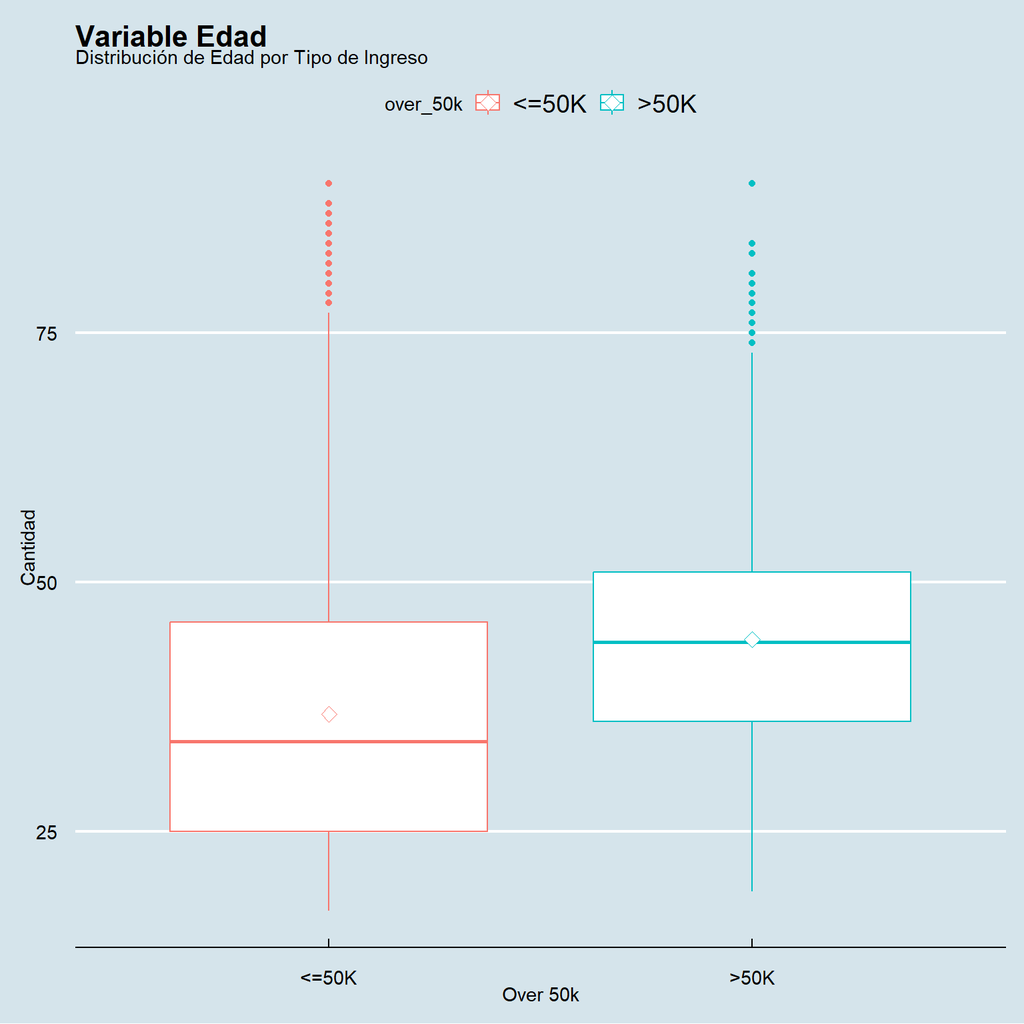

```r
ggplot(adultos, aes(x = over_50k, y = age, color=over_50k)) +
  geom_boxplot() +
  stat_summary(fun.y = "mean", geom = "point", shape = 23, size = 3, fill = "white") +
   labs(title = "Variable Edad",
       subtitle = "Distribución de Edad por Tipo de Ingreso",
       x = "Over 50k", y = "Cantidad") +
  theme_economist()
```

### Variable Capital Gain

Ahora veamos como se comporta la variable de Capital Ganado

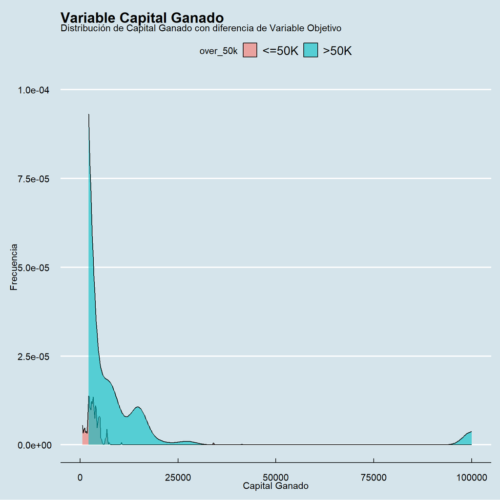

```r
ggplot(adultos, aes(x = capital_gain, fill = over_50k)) +
    geom_density(alpha = .6) + # Grado de transparencia para ver la gráfica traspuesta
  scale_y_continuous(limits = c(0, .0001)) + # Para poder visualizar mejor la gráfica
    labs(title = "Variable Capital Ganado",
       subtitle = "Distribución de Capital Ganado con diferencia de Variable Objetivo",
       x = "Capital Ganado", y = "Frecuencia") +
  theme_economist()
```

Podemos ver que las personas que perciben un ingreso mayor a 50K USD tienden a tener capital ganado en comparación con los que no perciben un ingreso mayor a 50k USD.

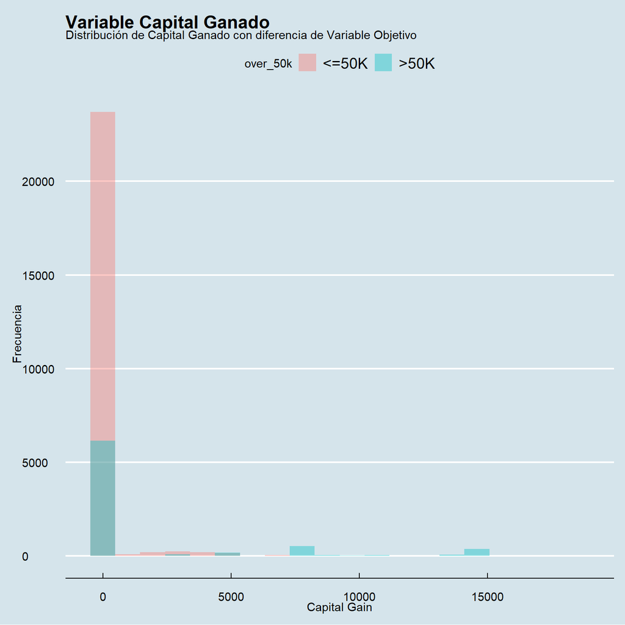

```r
ggplot(adultos |>  filter(capital_gain<20000), aes(x = capital_gain, fill = over_50k)) +
    geom_histogram(position = "identity", alpha = 0.4, bins=20) + # Posición identity para que se puedan trasponer los histogramas
     labs(title = "Variable Capital Ganado",
       subtitle = "Distribución de Capital Ganado con diferencia de Variable Objetivo",
       x = "Capital Gain", y = "Frecuencia") +
  theme_economist()
```

Podemos corroborar lo que mencionamos arriba, donde si bien la mayoría de las personas no ganan capital, cuando ellas documentan que perciben cierto capital tienen más probabilidad de ser del grupo de personas que perciben un ingreso mayor a 50 K USD.

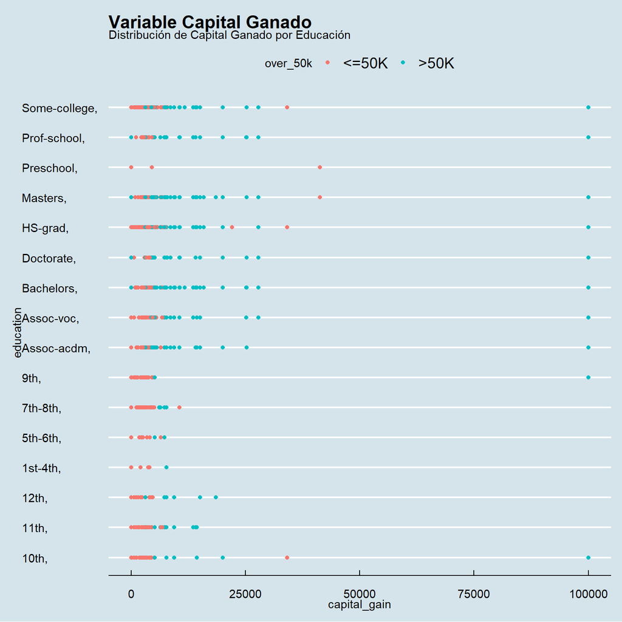

```r
ggplot(adultos, aes(x = capital_gain, y = education, color=over_50k)) +
  geom_point() +
   labs(title = "Variable Capital Ganado",
       subtitle = "Distribución de Capital Ganado por Educación") +
  theme_economist()
```

Podemos ver que las personas que tienen un nivel académico bajo tienden a reportar un capital ganado bajo o nulo y a la vez este repercute en el ingreso anual que perciben en el año.

### Variable Capital Loss

Ahora analizaremos la variable de Capital Perdido

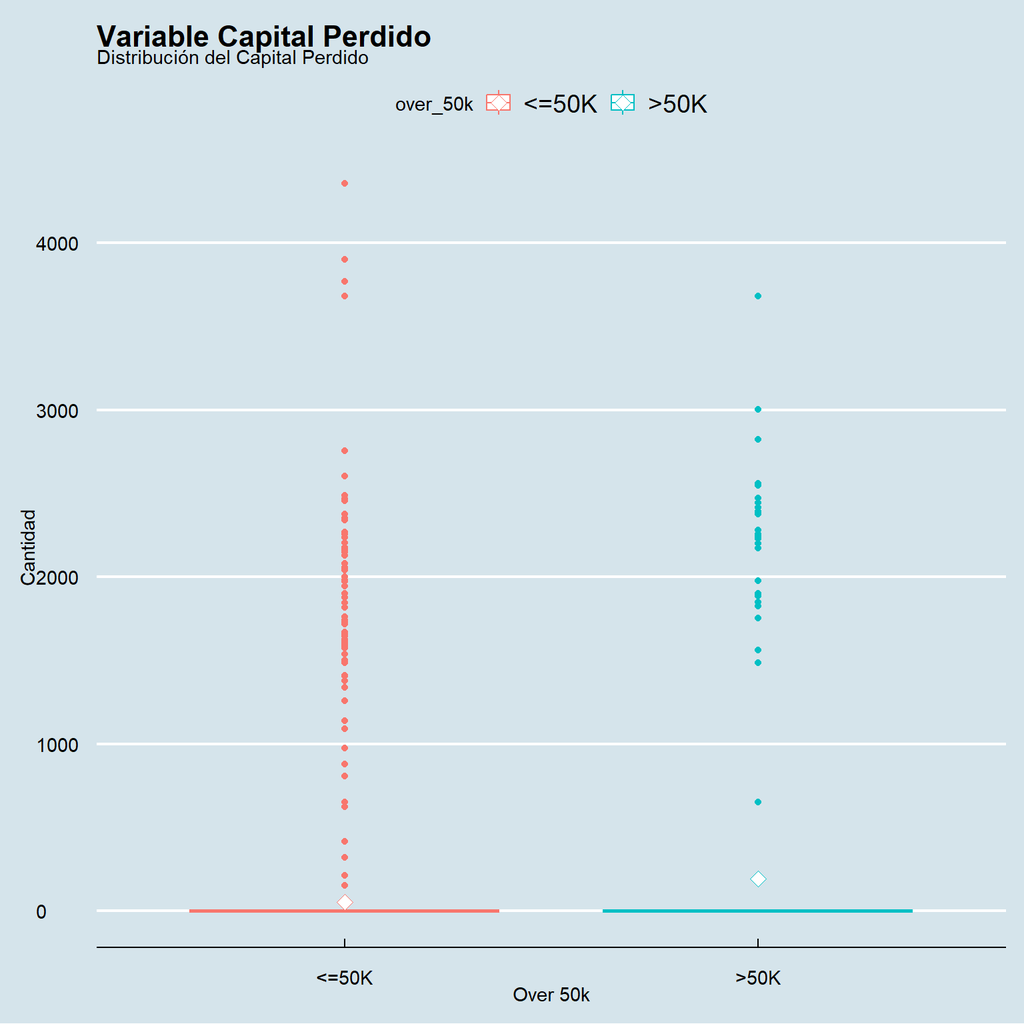

```r
ggplot(adultos, aes(x = over_50k, y = capital_loss, color=over_50k)) +
  geom_boxplot() +
  stat_summary(fun.y = "mean", geom = "point", shape = 23, size = 3, fill = "white") +
   labs(title = "Variable Capital Perdido",
       subtitle = "Distribución del Capital Perdido",
       x = "Over 50k", y = "Cantidad") +
  theme_economist()
```

Podemos ver que los percentiles 25, 50 y 75 se encuentran en 0, señalando que la mayor parte de las personas no tienen capital perdido, sin embargo al ver la distribución podemos determinar que en el caso que una persona tenga perdida de capital, es muy probable que si ella percibe un ingreso menor a 50 mil USD sea baja y visceversa, determinando esto también por donde se posiciona la media de cada grupo. (Las personas conun ingreso más alto son menos en los casos de perdida, sin embargo, su media es más alta)

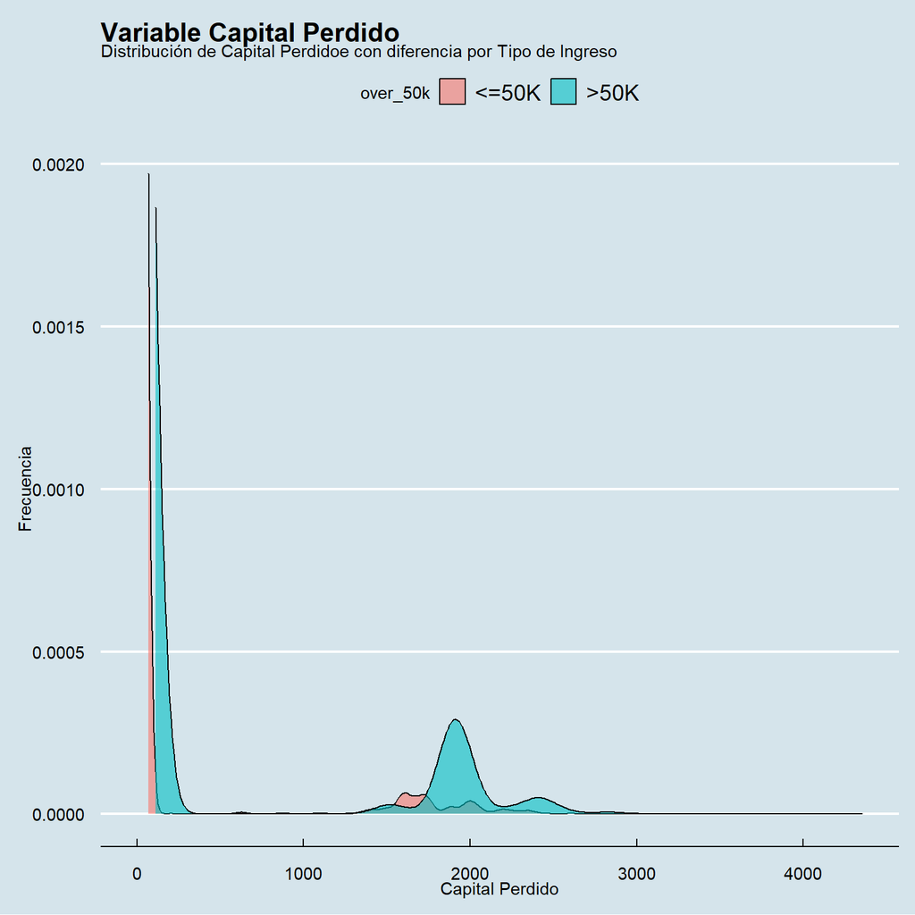

```r
ggplot(adultos, aes(x = capital_loss, fill = over_50k)) +
    geom_density(alpha = .6) +
  scale_y_continuous(limits = c(0, .002)) +
    labs(title = "Variable Capital Perdido",
       subtitle = "Distribución de Capital Perdidoe con diferencia por Tipo de Ingreso",
       x = "Capital Perdido", y = "Frecuencia") +
  theme_economist()
```

Esta gráfica confirma la observación marcada anteriormente con respecto al capital perdido, lo importante a resaltas es que al ser está gráfica la densidad de la distribución se aprecia de mejor manera.

### Variable Hours_per_week

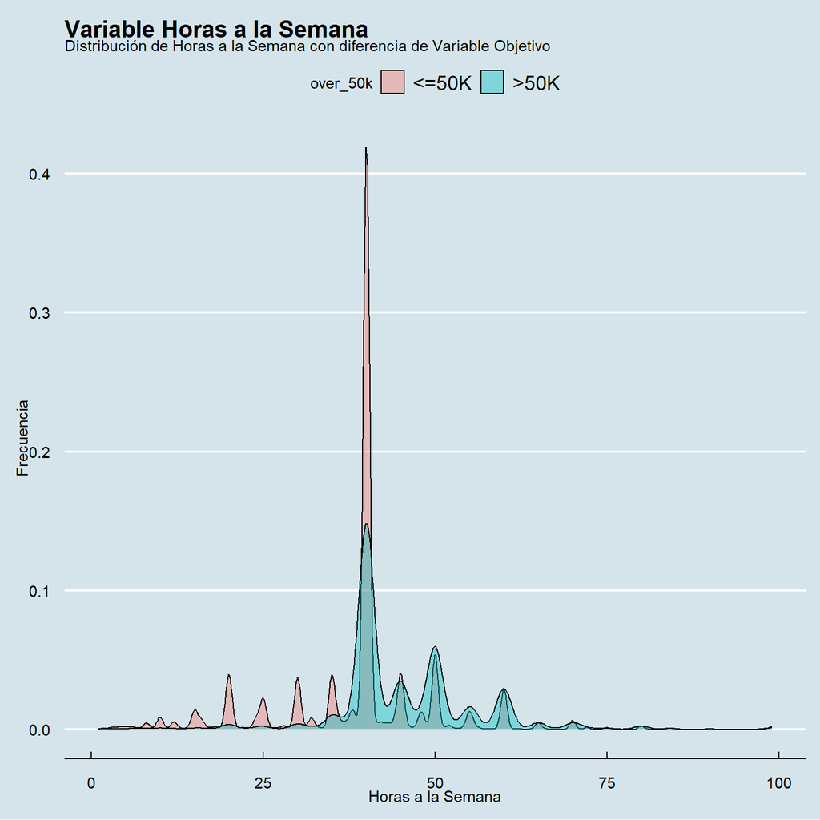

```r
ggplot(adultos, aes(x =  hours_per_week, fill = over_50k)) +
    geom_density(position = "identity", alpha = 0.4, bins=20) +
    labs(title = "Variable Horas a la Semana",
       subtitle = "Distribución de Horas a la Semana con diferencia de Variable Objetivo",
       x = "Horas a la Semana", y = "Frecuencia") +
  theme_economist()
```

### Variable fnlwgt

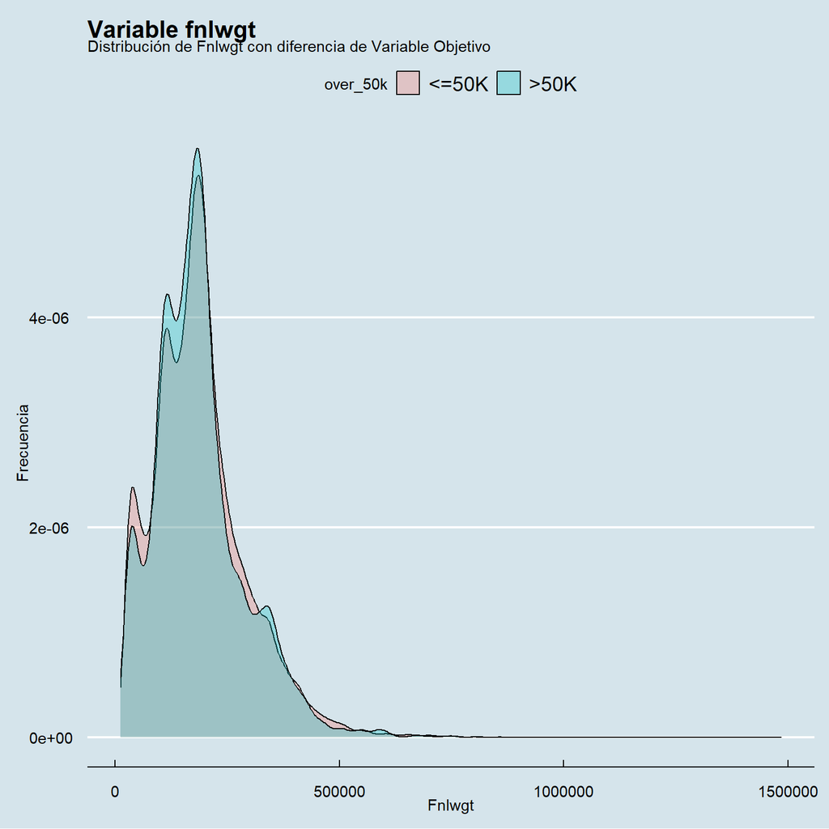

```r
ggplot(adultos, aes(x = fnlwgt, fill = over_50k)) +
    geom_density(alpha = .3) +
    labs(title = "Variable fnlwgt",
       subtitle = "Distribución de Fnlwgt con diferencia de Variable Objetivo",
       x = "Fnlwgt", y = "Frecuencia") +
  theme_economist()
```

Podemos ver que no existe ningún patrón entre las dos distribuciones.

### Variable Clase de Trabajo

Analizaremos la variable **Clase de Trabajo** y su relación con la variable objetivo:

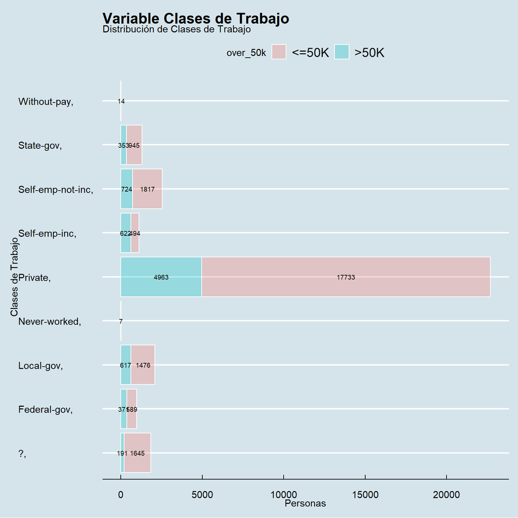

```r
  ggplot(adultos, aes(y = workclass, fill=over_50k)) +
  geom_bar(color = "white", alpha = 0.3) +
  labs(title = "Variable Clases de Trabajo",
       subtitle = "Distribución de Clases de Trabajo",
       x = "Personas", y = "Clases de Trabajo") +
  geom_text(size = 2.5,stat='count', aes(label=after_stat(count)), position=position_stack(vjust=0.5)) +
  theme_economist()
```

### Variable Estado Civil

Analizaremos la variable **Estado Civil** y su relación con la variable objetivo:

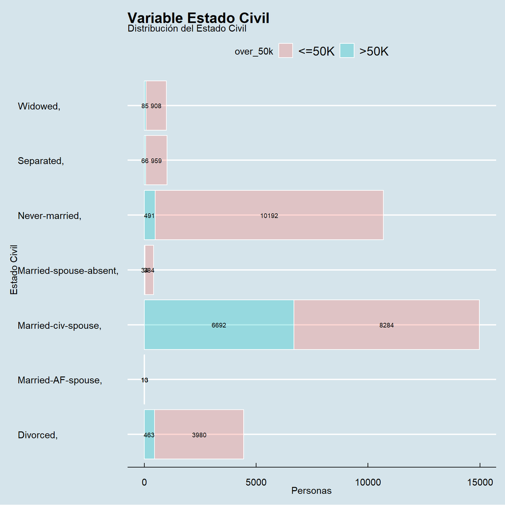

```r
  ggplot(adultos, aes(y = marital_status, fill=over_50k)) +
  geom_bar(color = "white", alpha = 0.3) +
  labs(title = "Variable Estado Civil",
       subtitle = "Distribución del Estado Civil",
       x = "Personas", y = "Estado Civil") +
  geom_text(size = 2.5,stat='count', aes(label=after_stat(count)), position=position_stack(vjust=0.5)) +
  theme_economist()
```

Podemos ver un comportamiento muy importante en la clase donde la gente se ha casado de manera civil, teniendo una gran cantidad y proporción mucho más favorable para los individuos que ganan más de 50 mil USD al año.

### Variable Ocupación

Analizaremos la variable *Ocupación** y su relación con la variable objetivo:

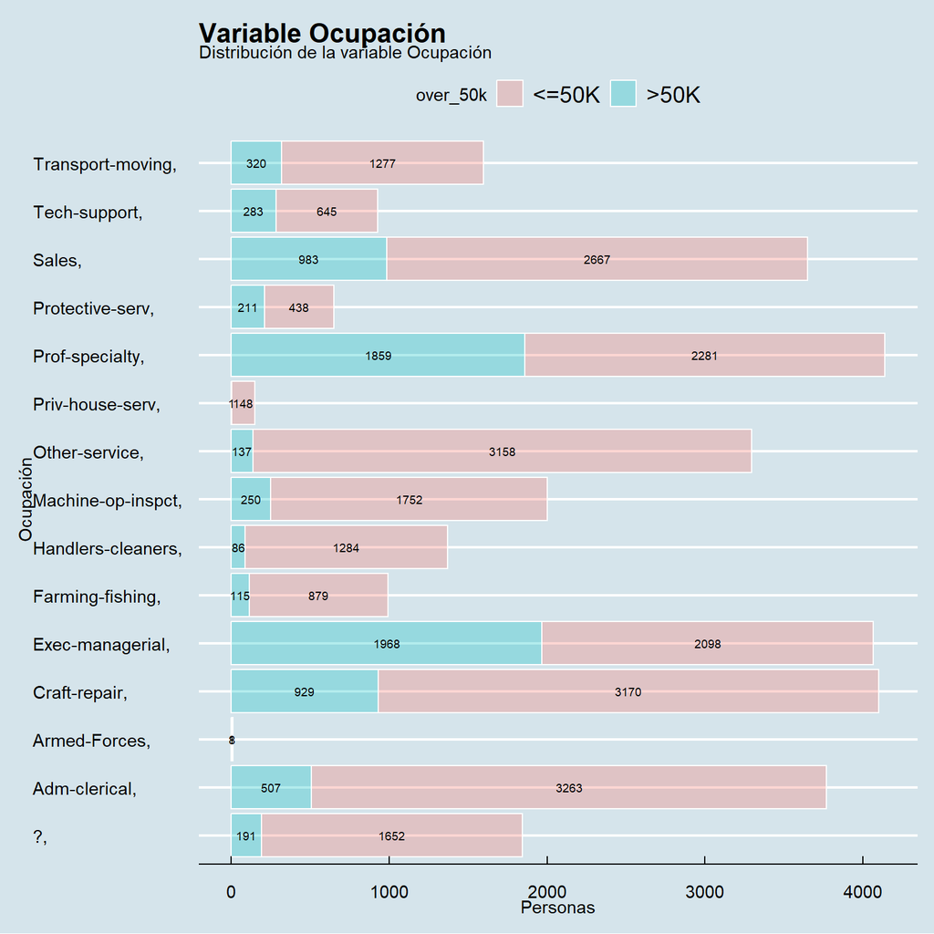

```r
  ggplot(adultos, aes(y = occupation, fill=over_50k)) +
  geom_bar(color = "white", alpha = 0.3) +
  labs(title = "Variable Ocupación",
       subtitle = "Distribución de la variable Ocupación",
       x = "Personas", y = "Ocupación") +
  geom_text(size = 2.5,stat='count', aes(label=after_stat(count)), position=position_stack(vjust=0.5)) +
  theme_economist()
```

Como era de esperarse las clases que hacen una diferencia en su distribución son **Prof-Speciality** y **Exec-Managerial** por el tipo de ingreso que llevan estos dos grupos de personas.

### Variable Relación

Analizaremos la variable *Relación** y su relación con la variable objetivo:

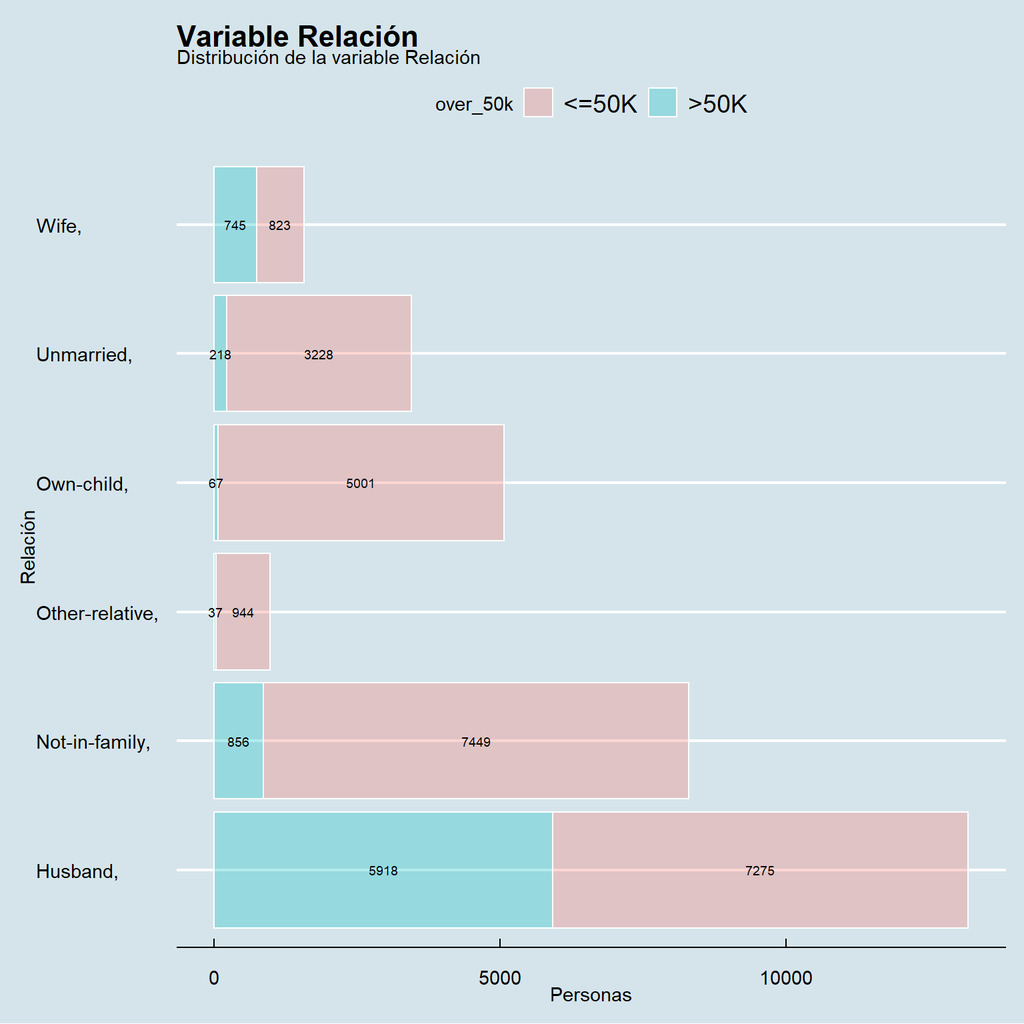

```r
  ggplot(adultos, aes(y = relationship, fill=over_50k)) +
  geom_bar(color = "white", alpha = 0.3) +
  labs(title = "Variable Relación",
       subtitle = "Distribución de la variable Relación",
       x = "Personas", y = "Relación") +
  geom_text(size = 2.5,stat='count', aes(label=after_stat(count)), position=position_stack(vjust=0.5)) +
  theme_economist()
```

Vemos aquí que los jedes de familia son en su mayoría los que perciben un ingreso mayor a 50 mil dólares anuales.

### Variable Raza

Analizaremos la variable *Raza** y su relación con la variable objetivo:

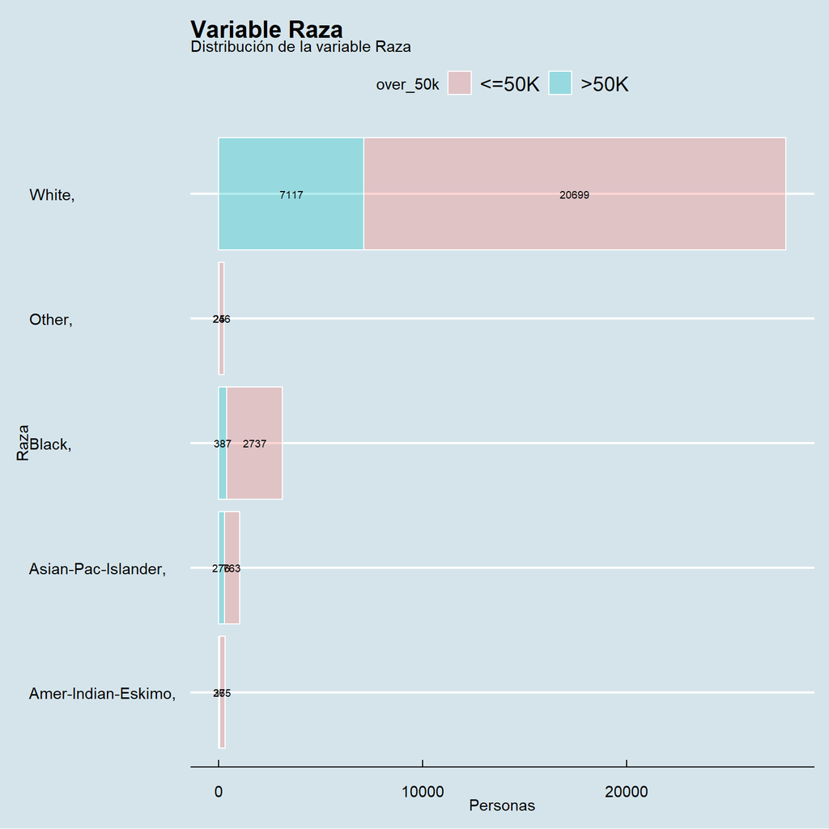

```r
  ggplot(adultos, aes(y = race, fill=over_50k)) +
  geom_bar(color = "white", alpha = 0.3) +
  labs(title = "Variable Raza",
       subtitle = "Distribución de la variable Raza",
       x = "Personas", y = "Raza") +
  geom_text(size = 2.5,stat='count', aes(label=after_stat(count)), position=position_stack(vjust=0.5)) +
  theme_economist()
```

Podemos ver que los asiáticos y blancos son los más propensos a percibir un ingreso superior a 50 mil dólares anuales.

### Variable Sexo

Analizaremos la variable *Sexo** y su relación con la variable objetivo:

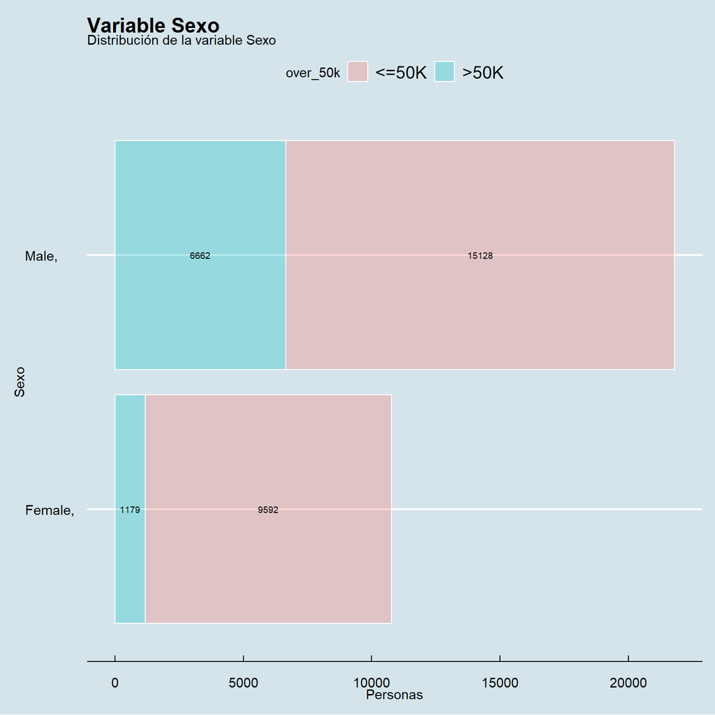

```r
  ggplot(adultos, aes(y = sex, fill=over_50k)) +
  geom_bar(color = "white", alpha = 0.3) +
  labs(title = "Variable Sexo",
       subtitle = "Distribución de la variable Sexo",
       x = "Personas", y = "Sexo") +
  geom_text(size = 2.5,stat='count', aes(label=after_stat(count)), position=position_stack(vjust=0.5)) +
  theme_economist()
```

Podemos ver que al agruparse la población, el sexo masculino tiene una mayor posibilidad de percibir un ingreso superior a 50 mil dólares anuales.

### Variable País

Analizaremos la variable *País** y su relación con la variable objetivo:

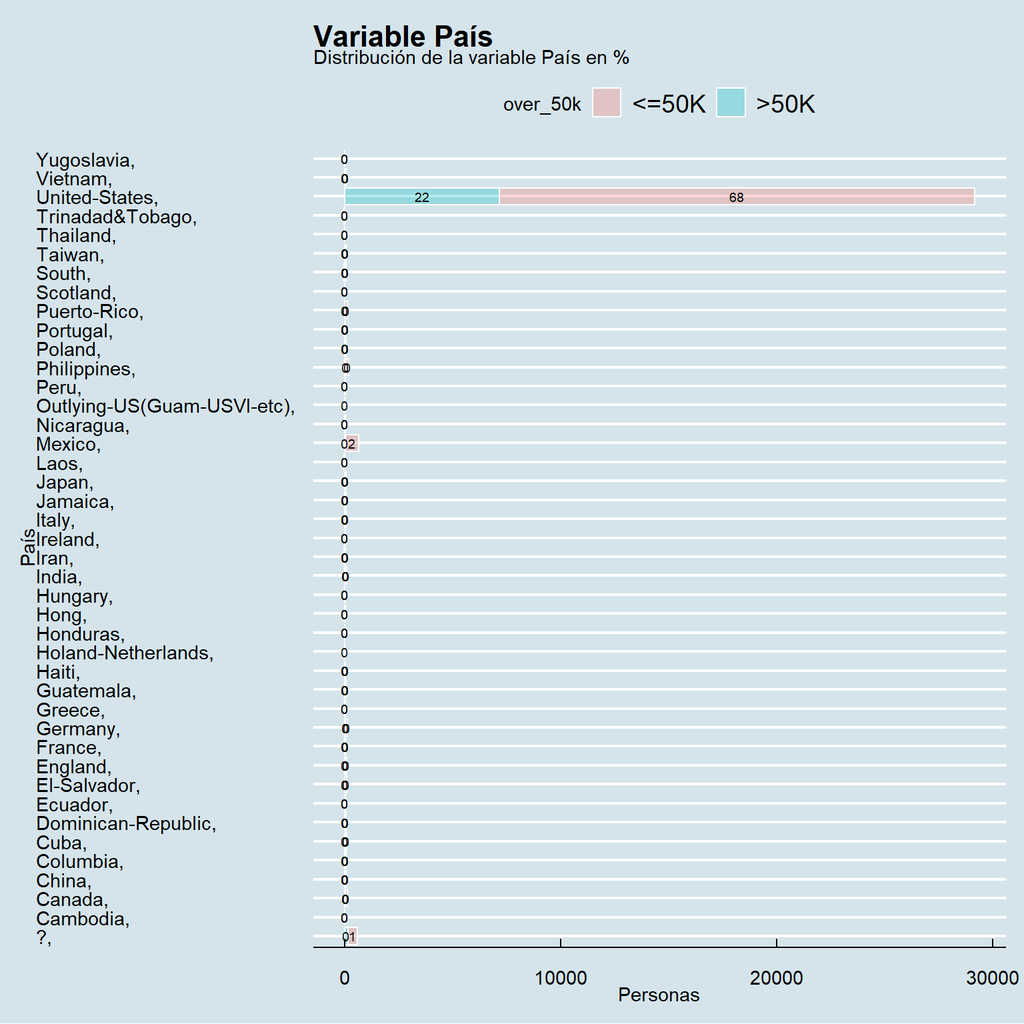

```r
  ggplot(adultos, aes(y = native_country, fill=over_50k)) +
  geom_bar(color = "white", alpha = 0.3) +
  labs(title = "Variable País",
       subtitle = "Distribución de la variable País en %",
       x = "Personas", y = "País") +
  geom_text(size = 2.5,stat='count', aes(label=after_stat(round(count / sum(count),2) * 100)), position=position_stack(vjust=0.5)) +
  theme_economist()
```

Podemos ver que alrededor del 90% de las personas han nacido en Estados Unidos.

# Introducción Teórica

Explicaremos brevemente cada uno de los algoritmos que se usarán en esta práctica:

## KNN

Es uno de los modelos de Machine Learning más sencillos.

Su lógica es asumir la similaridad entre un nuevo caso o dato y los otros puntos disponibles, colocando este nuevo punto en las categorías previamente definidas.

Algoritmo usado para regresión y clasificación.

Es un algoritmo de aprendizaje vago (lazy learner algorithm) ya que hace un almacenamiento de los datos de entrenamiento y espera hasta que reciba los datos de testing para poder empezar a clasificar, haciendo que tome menos tiempo en entrenamiento, pero más tiempo prediciendo.

El funcionamiento del algoritmo de KNN es el siguiente:

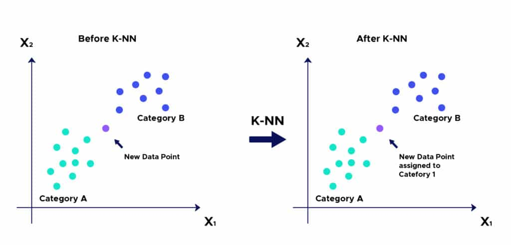

Fuente: https://www.javatpoint.com/k-nearest-neighbor-algorithm-for-machine-learning

## Árboles de decisión

Los arboles de decisión es un modelo de aprendizaje supervisado que sive para resolver problemas de clasificación y regresión, también conocido como `Classification And Regression Tree (CART) algorithm.`

Con base a la variable objetivo podemos definir los árboles de decisión en dos tipos:

1. Arboles de Decisión de Variables Categóricas
2. Arboles de Decisión de Variables Continuas

# Fase 1-2-3: muestreo-exploración-modificación

Ahora examinaremos los datos con el objetivo de poder tomar **decisiones que deberíamos adoptar**. Por ejemplo:

- ¿Necesitamos **muestreo**? ¿De qué forma? ¿Podremos permitirnos crear un dataset de **validación**?
- ¿De qué **tipo** es cada variable? ¿Tenemos **problemas de codificación o rango**?
- ¿Cómo **afectan las predictoras** a los niveles de la variable objetivo?
- ¿Hay problemas de **dependencia** entre las variables?
- ¿Necesitamos **recategorizar** las variables?
- ¿Tenemos **datos atípicos**? ¿Tenemos **datos ausentes**? ¿Cómo imputarlos?
- ¿Necesitaremos hacer **One Hot Encoding** a nuestras variables categóricas?

La **filosofía** será la siguiente:

- modificaciones «estructurales» las hacemos fuera de la receta (modificando la base de datos)
- modificaciones más concretas para un algoritmo dentro de la receta (sin modificar la base de datos).

## Factores

Una de las primeras decisiones será dotar a las variables de su **tipología correcta**: debemos decidir si las variables de tipo texto son **variables cualitativas** (factores) o meros id’s.

```r
adultos |>
  select(where(is.character)) |>
  glimpse()
```

```
Rows: 32,561
Columns: 9
$ workclass      <chr> "State-gov,", "Self-emp-not-inc,", "Private,"…
$ education      <chr> "Bachelors,", "Bachelors,", "HS-grad,", "11th…
$ marital_status <chr> "Never-married,", "Married-civ-spouse,", "Div…
$ occupation     <chr> "Adm-clerical,", "Exec-managerial,", "Handler…
$ relationship   <chr> "Not-in-family,", "Husband,", "Not-in-family,…
$ race           <chr> "White,", "White,", "White,", "Black,", "Blac…
$ sex            <chr> "Male,", "Male,", "Male,", "Male,", "Female,"…
$ native_country <chr> "United-States,", "United-States,", "United-S…
$ over_50k       <chr> "<=50K", "<=50K", "<=50K", "<=50K", "<=50K", …
```

Todas las variables de tipo texto representan **categorías de una cualitativa** así que las convertimos todas ellas a factor (modificación estructural –> fuera de la receta)

```r
adultos <-
  adultos |>
  mutate(across(where(is.character),  ~str_replace_all(., ",", "")), across(where(is.character), as_factor))
adultos |> select(where(is.factor))
```

```
# A tibble: 32,561 × 9
   workc…¹ educa…² marit…³ occup…⁴ relat…⁵ race  sex   nativ…⁶ over_…⁷
   <fct>   <fct>   <fct>   <fct>   <fct>   <fct> <fct> <fct>   <fct>
 1 State-… Bachel… Never-… Adm-cl… Not-in… White Male  United… <=50K
 2 Self-e… Bachel… Marrie… Exec-m… Husband White Male  United… <=50K
 3 Private HS-grad Divorc… Handle… Not-in… White Male  United… <=50K
 4 Private 11th    Marrie… Handle… Husband Black Male  United… <=50K
 5 Private Bachel… Marrie… Prof-s… Wife    Black Fema… Cuba    <=50K
 6 Private Masters Marrie… Exec-m… Wife    White Fema… United… <=50K
 7 Private 9th     Marrie… Other-… Not-in… Black Fema… Jamaica <=50K
 8 Self-e… HS-grad Marrie… Exec-m… Husband White Male  United… >50K
 9 Private Masters Never-… Prof-s… Not-in… White Fema… United… >50K
10 Private Bachel… Marrie… Exec-m… Husband White Male  United… >50K
# … with 32,551 more rows, and abbreviated variable names ¹workclass,
#   ²education, ³marital_status, ⁴occupation, ⁵relationship,
#   ⁶native_country, ⁷over_50k
```

### Ordinales

Podemos ver que de todas nuestras variables la educación puede tener un orden en sus variables.

Primero veamos su distribución:

```r
adultos |>
  count(education) |>
  mutate(porc = 100*n/sum(n))
```

```
# A tibble: 16 × 3
   education        n   porc
   <fct>        <int>  <dbl>
 1 Bachelors     5355 16.4
 2 HS-grad      10501 32.3
 3 11th          1175  3.61
 4 Masters       1723  5.29
 5 9th            514  1.58
 6 Some-college  7291 22.4
 7 Assoc-acdm    1067  3.28
 8 Assoc-voc     1382  4.24
 9 7th-8th        646  1.98
10 Doctorate      413  1.27
11 Prof-school    576  1.77
12 5th-6th        333  1.02
13 10th           933  2.87
14 1st-4th        168  0.516
15 Preschool       51  0.157
16 12th           433  1.33
```

Vemos que son 16 niveles de variable que reduciremos a 5 niveles.

```r
adultos <- adultos |>
 mutate(
    education_transformed = as.factor(case_when(
      education == "Doctorate"  ~ as.character("Grado 5"),
      education == "Prof-school" | education == "Masters"  ~ as.character("Grado 4"),
      education == "Some-college" | education == "Bachelors"  ~ as.character("Grado 3"),
      education == "Assoc-acdm" | education == "Assoc-voc"  ~ as.character("Grado 2"),
      TRUE ~ as.character("Grado 1")
    )))

knitr::kable(adultos |> select(education, education_transformed) |>  unique())
```

| education | education_transformed |
| --- | --- |
| Bachelors | Grado 3 |
| HS-grad | Grado 1 |
| 11th | Grado 1 |
| Masters | Grado 4 |
| 9th | Grado 1 |
| Some-college | Grado 3 |
| Assoc-acdm | Grado 2 |
| Assoc-voc | Grado 2 |
| 7th-8th | Grado 1 |
| Doctorate | Grado 5 |
| Prof-school | Grado 4 |
| 5th-6th | Grado 1 |
| 10th | Grado 1 |
| 1st-4th | Grado 1 |
| Preschool | Grado 1 |
| 12th | Grado 1 |

Tras ello convertiremos `education_transformed` a cualitativa pero ordinal.

```r
adultos <-
  adultos |>
  mutate(education_transformed = factor(education_transformed, levels = c("Grado 1", "Grado 2", "Grado 3", "Grado 4", "Grado 5"),
                       ordered = TRUE))
knitr::kable(adultos |> select(education_transformed) |> arrange(desc(education_transformed)) |> unique() )
```

| education_transformed |
| --- |
| Grado 5 |
| Grado 4 |
| Grado 3 |
| Grado 2 |
| Grado 1 |

## Variables cuali

Una vez convertidas en cualitativas analicemos cada una de ellas. La idea básica es la siguiente: ver que peso suponen cada nivel en las variables, y además, ver como **afectan los niveles a la variable objetivo**.

### Variable workclass

Ahora procederemos a ver cómo se distribuye la variable **clase de trabajo**:

```r
adultos |>
  count(workclass, sort = TRUE) |>
  mutate(porc = 100*n/sum(n), cumsum(porc))
```

```
# A tibble: 9 × 4
  workclass            n    porc `cumsum(porc)`
  <fct>            <int>   <dbl>          <dbl>
1 Private          22696 69.7              69.7
2 Self-emp-not-inc  2541  7.80             77.5
3 Local-gov         2093  6.43             83.9
4 ?                 1836  5.64             89.6
5 State-gov         1298  3.99             93.6
6 Self-emp-inc      1116  3.43             97.0
7 Federal-gov        960  2.95             99.9
8 Without-pay         14  0.0430          100.
9 Never-worked         7  0.0215          100
```

```r
adultos  |> group_by(workclass) |>
  count(over_50k) |>
  mutate(porc = 100*n/sum(n), cumul = cumsum(porc), nSum = sum(n)) |>  arrange(-nSum, -n) |>
  select(-nSum) |> ungroup()
```

```
# A tibble: 16 × 5
   workclass        over_50k     n  porc cumul
   <fct>            <fct>    <int> <dbl> <dbl>
 1 Private          <=50K    17733  78.1  78.1
 2 Private          >50K      4963  21.9 100
 3 Self-emp-not-inc <=50K     1817  71.5  71.5
 4 Self-emp-not-inc >50K       724  28.5 100
 5 Local-gov        <=50K     1476  70.5  70.5
 6 Local-gov        >50K       617  29.5 100
 7 ?                <=50K     1645  89.6  89.6
 8 ?                >50K       191  10.4 100
 9 State-gov        <=50K      945  72.8  72.8
10 State-gov        >50K       353  27.2 100
11 Self-emp-inc     >50K       622  55.7 100
12 Self-emp-inc     <=50K      494  44.3  44.3
13 Federal-gov      <=50K      589  61.4  61.4
14 Federal-gov      >50K       371  38.6 100
15 Without-pay      <=50K       14 100   100
16 Never-worked     <=50K        7 100   100
```

Podemos apreciar que existen ciertas agrupaciones que hacen sentido como `Self-emp-inc` y `Self-emp-not-inc` en un nuevo grupo llamado `Self-Emp` , así como `Local-Gov` y `State-Gov` en `Other-Gov`. También renombraremos el tipo **?** a `Desconocido`.

```r
adultos <- adultos |>
 mutate(
    workclass_transformed = as.factor(case_when(
      workclass == "?"  ~ as.character("Desconocido"),
      workclass == "Local-gov" | workclass == "State-gov"  ~ as.character("Other-Gov"),
      workclass == "Self-emp-inc" | workclass == "Self-emp-not-inc"  ~ as.character("Self-Emp"),
      TRUE ~ as.character(workclass)
    )))

knitr::kable(adultos |> select(workclass, workclass_transformed) |>  unique())
```

| workclass | workclass_transformed |
| --- | --- |
| State-gov | Other-Gov |
| Self-emp-not-inc | Self-Emp |
| Private | Private |
| Federal-gov | Federal-gov |
| Local-gov | Other-Gov |
| ? | Desconocido |
| Self-emp-inc | Self-Emp |
| Without-pay | Without-pay |
| Never-worked | Never-worked |

### Variable Estado Civil

Ahora procederemos a ver cómo se distribuye la variable **Estado Civil**:

```r
adultos |>
  count(marital_status, sort = TRUE) |>
  mutate(porc = 100*n/sum(n), cumsum(porc))
```

```
# A tibble: 7 × 4
  marital_status            n    porc `cumsum(porc)`
  <fct>                 <int>   <dbl>          <dbl>
1 Married-civ-spouse    14976 46.0              46.0
2 Never-married         10683 32.8              78.8
3 Divorced               4443 13.6              92.4
4 Separated              1025  3.15             95.6
5 Widowed                 993  3.05             98.6
6 Married-spouse-absent   418  1.28             99.9
7 Married-AF-spouse        23  0.0706          100
```

```r
adultos  |> group_by(marital_status) |>
  count(over_50k) |>
  mutate(porc = 100*n/sum(n), cumul = cumsum(porc), nSum = sum(n)) |>  arrange(-nSum, -n) |>
  select(-nSum) |> ungroup()
```

```
# A tibble: 14 × 5
   marital_status        over_50k     n  porc cumul
   <fct>                 <fct>    <int> <dbl> <dbl>
 1 Married-civ-spouse    <=50K     8284 55.3   55.3
 2 Married-civ-spouse    >50K      6692 44.7  100
 3 Never-married         <=50K    10192 95.4   95.4
 4 Never-married         >50K       491  4.60 100
 5 Divorced              <=50K     3980 89.6   89.6
 6 Divorced              >50K       463 10.4  100
 7 Separated             <=50K      959 93.6   93.6
 8 Separated             >50K        66  6.44 100
 9 Widowed               <=50K      908 91.4   91.4
10 Widowed               >50K        85  8.56 100
11 Married-spouse-absent <=50K      384 91.9   91.9
12 Married-spouse-absent >50K        34  8.13 100
13 Married-AF-spouse     <=50K       13 56.5   56.5
14 Married-AF-spouse     >50K        10 43.5  100
```

Podemos apreciar que existen ciertas agrupaciones que hacen sentido como `Married-civ-spouse` y `Married-AF-spouse` en un nuevo grupo llamado `Married` , así como `Divorced`, `Separated`, `Widowed` y `Married-spouse-absent` en `Complicated`.

```r
adultos <- adultos |>
 mutate(
    marital_status_transformed = as.factor(case_when(
      marital_status == "Married-civ-spouse" | marital_status == "Married-AF-spouse"  ~ as.character("Married"),
      marital_status == "Never-married"  ~ as.character("Never-married"),
      TRUE ~ as.character("Complicated")
    )))

knitr::kable(adultos |> select(marital_status, marital_status_transformed) |>  unique())
```

| marital_status | marital_status_transformed |
| --- | --- |
| Never-married | Never-married |
| Married-civ-spouse | Married |
| Divorced | Complicated |
| Married-spouse-absent | Complicated |
| Separated | Complicated |
| Married-AF-spouse | Married |
| Widowed | Complicated |

### Variable Ocupación

Ahora procederemos a ver cómo se distribuye la variable **Ocupación**:

```r
adultos |>
  count(occupation, sort = TRUE) |>
  mutate(porc = 100*n/sum(n), cumsum(porc))
```

```
# A tibble: 15 × 4
   occupation            n    porc `cumsum(porc)`
   <fct>             <int>   <dbl>          <dbl>
 1 Prof-specialty     4140 12.7              12.7
 2 Craft-repair       4099 12.6              25.3
 3 Exec-managerial    4066 12.5              37.8
 4 Adm-clerical       3770 11.6              49.4
 5 Sales              3650 11.2              60.6
 6 Other-service      3295 10.1              70.7
 7 Machine-op-inspct  2002  6.15             76.8
 8 ?                  1843  5.66             82.5
 9 Transport-moving   1597  4.90             87.4
10 Handlers-cleaners  1370  4.21             91.6
11 Farming-fishing     994  3.05             94.7
12 Tech-support        928  2.85             97.5
13 Protective-serv     649  1.99             99.5
14 Priv-house-serv     149  0.458           100.
15 Armed-Forces          9  0.0276          100
```

```r
adultos  |> group_by(occupation) |>
  count(over_50k) |>
  mutate(porc = 100*n/sum(n), cumul = cumsum(porc), nSum = sum(n)) |>  arrange(-nSum, -n) |>
  select(-nSum) |> ungroup()
```

```
# A tibble: 30 × 5
   occupation      over_50k     n  porc cumul
   <fct>           <fct>    <int> <dbl> <dbl>
 1 Prof-specialty  <=50K     2281  55.1  55.1
 2 Prof-specialty  >50K      1859  44.9 100
 3 Craft-repair    <=50K     3170  77.3  77.3
 4 Craft-repair    >50K       929  22.7 100
 5 Exec-managerial <=50K     2098  51.6  51.6
 6 Exec-managerial >50K      1968  48.4 100
 7 Adm-clerical    <=50K     3263  86.6  86.6
 8 Adm-clerical    >50K       507  13.4 100
 9 Sales           <=50K     2667  73.1  73.1
10 Sales           >50K       983  26.9 100
# … with 20 more rows
```

Podemos apreciar que existen ciertas agrupaciones que hacen sentido como `Prof-specialty` y `Exec-managerial` en un nuevo grupo llamado `High-Income` , así como `Protective-serv`, `Tech-support` y `Sales` en `Medium-Income` y el resto en `Low-Income`.

```r
adultos <- adultos |>
 mutate(
    occupation_transformed = as.factor(case_when(
      occupation == "Prof-specialty" | occupation == "Exec-managerial"  ~ as.character("High-Income"),
      occupation == "Protective-serv" | occupation == "Tech-support" | occupation == "Sales"   ~ as.character("Medium-Income"),
      TRUE ~ as.character("Low-Income")
    )))

knitr::kable(adultos |> select(occupation, occupation_transformed) |>  unique())
```

| occupation | occupation_transformed |
| --- | --- |
| Adm-clerical | Low-Income |
| Exec-managerial | High-Income |
| Handlers-cleaners | Low-Income |
| Prof-specialty | High-Income |
| Other-service | Low-Income |
| Sales | Medium-Income |
| Craft-repair | Low-Income |
| Transport-moving | Low-Income |
| Farming-fishing | Low-Income |
| Machine-op-inspct | Low-Income |
| Tech-support | Medium-Income |
| ? | Low-Income |
| Protective-serv | Medium-Income |
| Armed-Forces | Low-Income |
| Priv-house-serv | Low-Income |

### Variable Relación

Ahora procederemos a ver cómo se distribuye la variable **Relación**:

```r
adultos |>
  count(relationship, sort = TRUE) |>
  mutate(porc = 100*n/sum(n), cumsum(porc))
```

```
# A tibble: 6 × 4
  relationship       n  porc `cumsum(porc)`
  <fct>          <int> <dbl>          <dbl>
1 Husband        13193 40.5            40.5
2 Not-in-family   8305 25.5            66.0
3 Own-child       5068 15.6            81.6
4 Unmarried       3446 10.6            92.2
5 Wife            1568  4.82           97.0
6 Other-relative   981  3.01          100
```

```r
adultos  |> group_by(relationship) |>
  count(over_50k) |>
  mutate(porc = 100*n/sum(n), cumul = cumsum(porc), nSum = sum(n)) |>  arrange(-nSum, -n) |>
  select(-nSum) |> ungroup()
```

```
# A tibble: 12 × 5
   relationship   over_50k     n  porc cumul
   <fct>          <fct>    <int> <dbl> <dbl>
 1 Husband        <=50K     7275 55.1   55.1
 2 Husband        >50K      5918 44.9  100
 3 Not-in-family  <=50K     7449 89.7   89.7
 4 Not-in-family  >50K       856 10.3  100
 5 Own-child      <=50K     5001 98.7   98.7
 6 Own-child      >50K        67  1.32 100
 7 Unmarried      <=50K     3228 93.7   93.7
 8 Unmarried      >50K       218  6.33 100
 9 Wife           <=50K      823 52.5   52.5
10 Wife           >50K       745 47.5  100
11 Other-relative <=50K      944 96.2   96.2
12 Other-relative >50K        37  3.77 100
```

Podemos apreciar que existen ciertas agrupaciones que hacen sentido como `Wife` y `Husband` en un nuevo grupo llamado `Boss` , así como el resto en un grupo llamado `Otros`. Esto lo haremos directamente en la receta para dejar al algorimto KNN con esta transformación y el resto de los algoritmos sin esta transformación.

### Variable Raza

Ahora procederemos a ver cómo se distribuye la variable **Raza**:

```r
adultos |>
  count(race, sort = TRUE) |>
  mutate(porc = 100*n/sum(n), cumsum(porc))
```

```
# A tibble: 5 × 4
  race                   n   porc `cumsum(porc)`
  <fct>              <int>  <dbl>          <dbl>
1 White              27816 85.4             85.4
2 Black               3124  9.59            95.0
3 Asian-Pac-Islander  1039  3.19            98.2
4 Amer-Indian-Eskimo   311  0.955           99.2
5 Other                271  0.832          100
```

```r
adultos  |> group_by(race) |>
  count(over_50k) |>
  mutate(porc = 100*n/sum(n), cumul = cumsum(porc), nSum = sum(n)) |>  arrange(-nSum, -n) |>
  select(-nSum) |> ungroup()
```

```
# A tibble: 10 × 5
   race               over_50k     n  porc cumul
   <fct>              <fct>    <int> <dbl> <dbl>
 1 White              <=50K    20699 74.4   74.4
 2 White              >50K      7117 25.6  100
 3 Black              <=50K     2737 87.6   87.6
 4 Black              >50K       387 12.4  100
 5 Asian-Pac-Islander <=50K      763 73.4   73.4
 6 Asian-Pac-Islander >50K       276 26.6  100
 7 Amer-Indian-Eskimo <=50K      275 88.4   88.4
 8 Amer-Indian-Eskimo >50K        36 11.6  100
 9 Other              <=50K      246 90.8   90.8
10 Other              >50K        25  9.23 100
```

En este caso solo hace sentido agrupar `Amer-Indian-Eskimo` y `Other` en el grupo `Others`, las variables ya que son pocas y concisas, esto lo haremos directamente en la receta.

### Variable Sexo

Ahora procederemos a ver cómo se distribuye la variable **Sexo**:

```r
adultos |>
  count(sex, sort = TRUE) |>
  mutate(porc = 100*n/sum(n), cumsum(porc))
```

```
# A tibble: 2 × 4
  sex        n  porc `cumsum(porc)`
  <fct>  <int> <dbl>          <dbl>
1 Male   21790  66.9           66.9
2 Female 10771  33.1          100
```

```r
adultos  |> group_by(sex) |>
  count(over_50k) |>
  mutate(porc = 100*n/sum(n), cumul = cumsum(porc), nSum = sum(n)) |>  arrange(-nSum, -n) |>
  select(-nSum) |> ungroup()
```

```
# A tibble: 4 × 5
  sex    over_50k     n  porc cumul
  <fct>  <fct>    <int> <dbl> <dbl>
1 Male   <=50K    15128  69.4  69.4
2 Male   >50K      6662  30.6 100
3 Female <=50K     9592  89.1  89.1
4 Female >50K      1179  10.9 100
```

En este caso no hace sentido agrupar ya que son dos categorías muy presentes.

### Variable País

Ahora procederemos a ver cómo se distribuye la variable **País**:

```r
adultos |>
  count(native_country, sort = TRUE) |>
  mutate(porc = 100*n/sum(n), cumsum(porc))
```

```
# A tibble: 42 × 4
   native_country     n   porc `cumsum(porc)`
   <fct>          <int>  <dbl>          <dbl>
 1 United-States  29170 89.6             89.6
 2 Mexico           643  1.97            91.6
 3 ?                583  1.79            93.4
 4 Philippines      198  0.608           94.0
 5 Germany          137  0.421           94.4
 6 Canada           121  0.372           94.8
 7 Puerto-Rico      114  0.350           95.1
 8 El-Salvador      106  0.326           95.4
 9 India            100  0.307           95.7
10 Cuba              95  0.292           96.0
# … with 32 more rows
```

```r
adultos  |> group_by(native_country) |>
  count(over_50k) |>
  mutate(porc = 100*n/sum(n), cumul = cumsum(porc), nSum = sum(n)) |>  arrange(-nSum, -n) |>
  select(-nSum) |> ungroup()
```

```
# A tibble: 82 × 5
   native_country over_50k     n  porc cumul
   <fct>          <fct>    <int> <dbl> <dbl>
 1 United-States  <=50K    21999 75.4   75.4
 2 United-States  >50K      7171 24.6  100
 3 Mexico         <=50K      610 94.9   94.9
 4 Mexico         >50K        33  5.13 100
 5 ?              <=50K      437 75.0   75.0
 6 ?              >50K       146 25.0  100
 7 Philippines    <=50K      137 69.2   69.2
 8 Philippines    >50K        61 30.8  100
 9 Germany        <=50K       93 67.9   67.9
10 Germany        >50K        44 32.1  100
# … with 72 more rows
```

En este caso solo hace sentido dejar `United States` en un grupo, `Mexico` en otro grupo, `Philippines`,`Germany`,`Canada`,`India`,`England`,`South`,`Italy`,`Japan` y `Taiwan` en el grupo `High Income`, y el resto en el grupo `Others`.

```r
adultos <- adultos |>
 mutate(
    country_transformed = as.factor(case_when(
      native_country %in% c("Philippines","Germany","Canada","India","England","South","Italy","Japan","Taiwan")  ~ "High-Income",
      native_country == "United-States"   ~ as.character(native_country),
      native_country == "Mexico"   ~ as.character(native_country),
      TRUE ~ as.character("Others")
    )))

knitr::kable(adultos |> select(native_country, country_transformed) |>  unique())
```

| native_country | country_transformed |
| --- | --- |
| United-States | United-States |
| Cuba | Others |
| Jamaica | Others |
| India | High-Income |
| ? | Others |
| Mexico | Mexico |
| South | High-Income |
| Puerto-Rico | Others |
| Honduras | Others |
| England | High-Income |
| Canada | High-Income |
| Germany | High-Income |
| Iran | Others |
| Philippines | High-Income |
| Italy | High-Income |
| Poland | Others |
| Columbia | Others |
| Cambodia | Others |
| Thailand | Others |
| Ecuador | Others |
| Laos | Others |
| Taiwan | High-Income |
| Haiti | Others |
| Portugal | Others |
| Dominican-Republic | Others |
| El-Salvador | Others |
| France | Others |
| Guatemala | Others |
| China | Others |
| Japan | High-Income |
| Yugoslavia | Others |
| Peru | Others |
| Outlying-US(Guam-USVI-etc) | Others |
| Scotland | Others |
| Trinadad&Tobago | Others |
| Greece | Others |
| Nicaragua | Others |
| Vietnam | Others |
| Hong | Others |
| Ireland | Others |
| Hungary | Others |
| Holand-Netherlands | Others |

## Dependencia entre cuali

Podemos ejecutar un **contraste de independencia** (prueba $\chi^2$ de independencia) para tener mayor certeza de si la predictora es dependiente o no de la variable objetivo (si fuera independiente, no tendría sentido mantenerla)

Podemos hacerlo con **todas las variables a la vez** enfrentándola a la objetivo, entendiendo que cada columna juega el rol de una lista si usamos las funciones del paquete `{purrr}`

```r
chisq <-
  tibble("variable" = adultos |> select(where(is.factor)) |> names(),
         "p_value" = adultos |> select(where(is.factor)) |>
           map_dbl(.f = function(x) { chisq.test(adultos$over_50k, x)$p.value}))
chisq |> arrange(desc(p_value))
```

```
# A tibble: 14 × 2
   variable                     p_value
   <chr>                          <dbl>
 1 country_transformed        3.44e- 43
 2 native_country             2.21e- 44
 3 race                       2.31e- 70
 4 workclass_transformed      3.98e-154
 5 workclass                  2.03e-220
 6 education                  0
 7 marital_status             0
 8 occupation                 0
 9 relationship               0
10 sex                        0
11 over_50k                   0
12 education_transformed      0
13 marital_status_transformed 0
14 occupation_transformed     0
```

```r
chisq |> filter(p_value > 0.05)
```

```
# A tibble: 0 × 2
# … with 2 variables: variable <chr>, p_value <dbl>
```

**No hay evidencia suficiente para decir que existe predictora independiente de la objetivo** (al 95% de confianza) según la prueba de independencia realizada

## Variables numéricas

Para las numéricas el proceso será ligeramente diferente, ya que ya no toman modalidades, aunque la mayoría de ellas como veremos podrían funcionar tanto de cuanti como de cuali (recategorizadas)

### Horas de Trabajo a la Semana

```r
adultos |>
  count(hours_per_week, sort = TRUE) |>
  mutate(porc = 100*n/sum(n), cumul = cumsum(porc))
```

```
# A tibble: 94 × 4
   hours_per_week     n  porc cumul
            <dbl> <int> <dbl> <dbl>
 1             40 15217 46.7   46.7
 2             50  2819  8.66  55.4
 3             45  1824  5.60  61.0
 4             60  1475  4.53  65.5
 5             35  1297  3.98  69.5
 6             20  1224  3.76  73.3
 7             30  1149  3.53  76.8
 8             55   694  2.13  78.9
 9             25   674  2.07  81.0
10             48   517  1.59  82.6
# … with 84 more rows
```

```r
adultos <- adultos |>
 mutate(
    hours_per_week_transformed = as.factor(case_when(
      hours_per_week<40 ~ as.character("Menos de 40 Horas"),
      hours_per_week>40 ~ as.character("Más de 40 horas"),
      TRUE ~ as.character("40 Horas")
    )))
```

Ahora le daremos un orden a las nuevas categorías:

```r
adultos <-
  adultos |>
  mutate(hours_per_week_transformed = factor(hours_per_week_transformed, levels = c("Menos de 40 Horas", "40 Horas", "Más de 40 horas"),
                       ordered = TRUE))
knitr::kable(adultos |> select(hours_per_week_transformed) |> arrange(desc(hours_per_week_transformed)) |> unique() )
```

| hours_per_week_transformed |
| --- |
| Más de 40 horas |
| 40 Horas |
| Menos de 40 Horas |

Y así se vería:

```r
adultos|> group_by(hours_per_week_transformed) |>
  count(over_50k) |>
  mutate(porc = 100*n/sum(n), cumul = cumsum(porc), nSum = sum(n)) |>  arrange(-nSum, -n) |>
  select(-nSum) |> ungroup()
```

```
# A tibble: 6 × 5
  hours_per_week_transformed over_50k     n  porc cumul
  <ord>                      <fct>    <int> <dbl> <dbl>
1 40 Horas                   <=50K    11970 78.7   78.7
2 40 Horas                   >50K      3247 21.3  100
3 Más de 40 horas            <=50K     5725 59.8   59.8
4 Más de 40 horas            >50K      3856 40.2  100
5 Menos de 40 Horas          <=50K     7025 90.5   90.5
6 Menos de 40 Horas          >50K       738  9.51 100
```

## Colinealidad

Por último, nos falta comprobar los **problemas de colinealidad** entre las predictoras numéricas. Podemos tratar las **numéricas por separado** (aunque tengamos muchas que en realidad hacen más de cuali que de cuanti)

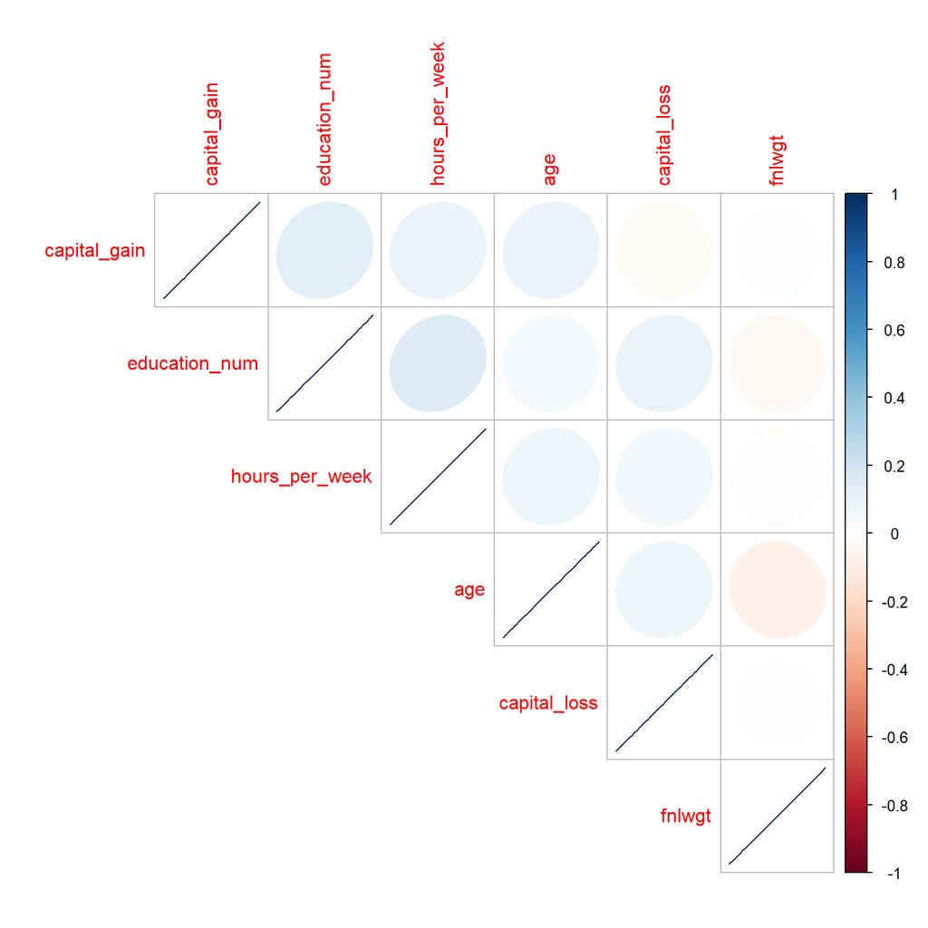

```r
library(corrr)
cor_matrix <- adultos |> select(where(is.numeric)) |> cor() |> round(2)

library(corrplot)
cor_matrix |>
  corrplot( method = 'ellipse', order = 'AOE', type = 'upper')
```

No parece existir una correlación elevada entre ninguna.

## Fase 3: modificación (fuera de la receta)

### Sampling

Con lo observado en la fase de exploración procederemos a hacer un **muestreo estratificado** del 25% ya que tenemos muchas filas (al menos para hacer pruebas).

```r
# Muestreo del 25%
adultos_sample <-
  adultos |>
  group_by(over_50k) |>
  slice_sample(prop = 0.25) |>
  ungroup()
```

## Fase 3: modificación (dentro de la receta)

### Partición

#### Test vs lo demás

Antes de nada deberemos realizar nuestras particiones, y primero dividiremos en **test y lo demás**, con `initial_split()`, teniendo 25% en test y 75% en todo lo demás

```r
# Partición 10% de test
adultos_split <- initial_split(adultos_sample, strata = over_50k, prop = 0.75)
adultos_split
```

```
<Training/Testing/Total>
<6105/2035/8140>
```

Fíjate que en `adultos_split` solo tenemos las instrucciones. Vamos a aplicarlas

```r
# Aplicamos partición
train_data <- training(adultos_split)
test_data <- testing(adultos_split)
```

Tras ello nunca está de más comprobar que efectivamente lo ha realizado de manera estratificada

```r
# Comprobamos estratos
train_data |> count(over_50k) |> mutate(porc = 100 * n / sum(n))
```

```
# A tibble: 2 × 3
  over_50k     n  porc
  <fct>    <int> <dbl>
1 <=50K     4635  75.9
2 >50K      1470  24.1
```

```r
test_data |> count(over_50k) |> mutate(porc = 100 * n / sum(n))
```

```
# A tibble: 2 × 3
  over_50k     n  porc
  <fct>    <int> <dbl>
1 <=50K     1545  75.9
2 >50K       490  24.1
```

#### Validación

```r
# Validación
set.seed(100)

cv_folds <-
 vfold_cv(train_data,
          v = 5,
          strata = over_50k,
          repeats = 3)
```

### Roles

Tras las particiones, el primer paso es **definir la receta**, indicándole el conjunto donde tenemos validación y train, y enfrentar `over_50k` con todas. Después lo que haremos será **asignar posibles roles** que nos puedan diferencias las acciones entre las variables

```r
# Receta
rec_adultos <-
  # Fórmula y datos
  recipe(data = train_data, over_50k ~ .)|>
  # Roles
  add_role(where(is.factor), new_role = "cuali") |>
  add_role(where(is.numeric), new_role = "cuanti") |>
  add_role(c(workclass, marital_status, occupation, native_country, hours_per_week, education, education_num), new_role = "Eliminar_KNN") |>
  add_role(c(workclass, marital_status, occupation, native_country, hours_per_week, education, education_num), new_role = "Eliminar_Arboles") |>
  add_role(c(workclass, marital_status, occupation, native_country, hours_per_week, education, education_num), new_role = "Eliminar_Random_Forests")
```

###Receta KNN

Ahora procederemos en crear la receta par el algoritmo KNN

```r
# Receta
KNN_rec_adultos <-
  rec_adultos  |>
  step_mutate(
    relationship =
                as.factor(case_when(
      relationship %in% c("Wife","Husband")  ~ "Boss",
      TRUE ~ "Others")),
    race =
                as.factor(case_when(
      race %in% c("Amer-Indian-Eskimo","Other")  ~ "Others",
      TRUE ~ as.character(race)))) |>
  step_rm(has_role("Eliminar_KNN"))|>
  # Detectar outliers
  step_mutate(across(where(is.numeric), function(x) { ifelse(abs(scores(x,type = "iqr")) > 1.5 & !is.na(x), NA, x) })) |>
  # Imputamos ausentes (podríamos dejarlas como una categoría más)
  step_impute_knn(has_role("cuanti")) |>
  step_impute_mode(has_role("cuali")) |>
  step_naomit(everything(), skip = TRUE) |>
  step_other(has_role("cuali"), threshold = .05, other = "Minority")  |>
  step_novel(all_nominal(), -all_outcomes()) |>
  # Reagrupamos
  step_range(has_role("cuanti")) |>
  step_normalize(has_role("cuanti")) |>
  step_dummy(all_nominal(), -all_outcomes())  |>
  step_zv(all_predictors()) |>
  step_corr(has_role("cuanti"), threshold = 0.7)  #|>
  # Sobremuestreo 50-50%
 #themis::step_upsample(over_50k, over_ratio = 1)
```

```r
prepped_data <-
  KNN_rec_adultos |>  # use the recipe object
  prep() |>  # perform the recipe on training data
  juice() # extract only the preprocessed dataframe

glimpse(prepped_data)
```

```
Rows: 6,105
Columns: 24
$ age                                      <dbl> -0.71179761, 0.6843…
$ fnlwgt                                   <dbl> -1.144084806, -0.78…
$ over_50k                                 <fct> <=50K, <=50K, <=50K…
$ relationship_Others                      <dbl> 1, 1, 1, 0, 1, 0, 0…
$ race_White                               <dbl> 1, 1, 0, 1, 1, 1, 1…
$ race_Minority                            <dbl> 0, 0, 0, 0, 0, 0, 0…
$ sex_Female                               <dbl> 1, 0, 0, 0, 1, 0, 0…
$ education_transformed_Grado.2            <dbl> 0, 0, 0, 0, 0, 1, 0…
$ education_transformed_Grado.3            <dbl> 1, 1, 1, 0, 1, 0, 0…
$ education_transformed_Grado.4            <dbl> 0, 0, 0, 0, 0, 0, 0…
$ education_transformed_Minority           <dbl> 0, 0, 0, 0, 0, 0, 0…
$ workclass_transformed_Other.Gov          <dbl> 0, 0, 1, 0, 0, 0, 0…
$ workclass_transformed_Private            <dbl> 1, 0, 0, 0, 0, 0, 0…
$ workclass_transformed_Self.Emp           <dbl> 0, 0, 0, 1, 0, 1, 1…
$ workclass_transformed_Minority           <dbl> 0, 1, 0, 0, 1, 0, 0…
$ marital_status_transformed_Married       <dbl> 0, 0, 0, 1, 0, 1, 1…
$ marital_status_transformed_Never.married <dbl> 1, 0, 1, 0, 1, 0, 0…
$ occupation_transformed_Low.Income        <dbl> 0, 0, 1, 1, 0, 1, 0…
$ occupation_transformed_Medium.Income     <dbl> 1, 0, 0, 0, 0, 0, 1…
$ country_transformed_United.States        <dbl> 1, 1, 1, 1, 1, 1, 1…
$ country_transformed_Minority             <dbl> 0, 0, 0, 0, 0, 0, 0…
$ hours_per_week_transformed_1             <dbl> -0.2236068, -0.2236…
$ hours_per_week_transformed_2             <dbl> -0.5, -0.5, -0.5, -…
$ hours_per_week_transformed_3             <dbl> 0.6708204, 0.670820…
```

### Receta CART

```r
# Receta
cart_rec_adultos <-
  rec_adultos  |>
  step_rm(has_role("Eliminar_Arboles"))|>
  # Detectar outliers
  step_mutate(across(where(is.numeric), function(x) { ifelse(abs(scores(x,type = "z")) >2.5 & !is.na(x), NA, x) })) |>
  # Imputamos ausentes (podríamos dejarlas como una categoría más)
  step_impute_median(has_role("cuanti")) |>
  step_impute_mode(has_role("cuali")) |>
  step_naomit(everything(), skip = TRUE) |>
  step_other(has_role("cuali"), threshold = .025, other = "Minority")  |>
  # Reagrupamos
  step_zv(all_predictors()) |>
  step_corr(has_role("cuanti"), threshold = 0.7)  |>
  # Sobremuestreo 50-50%
  themis::step_upsample(over_50k, over_ratio = 0.5)
```

```r
cart_prepped_data <-
  cart_rec_adultos |>  # use the recipe object
  prep() |>  # perform the recipe on training data
  juice() # extract only the preprocessed dataframe

glimpse(cart_prepped_data)
```

```
Rows: 6,952
Columns: 14
$ age                        <dbl> 34, 45, 29, 31, 27, 70, 35, 23, 2…
$ fnlwgt                     <dbl> 112820, 183168, 116820, 193565, 3…
$ relationship               <fct> Not-in-family, Unmarried, Own-chi…
$ race                       <fct> White, White, White, White, White…
$ sex                        <fct> Male, Female, Male, Male, Male, M…
$ capital_gain               <dbl> 2463, 0, 0, 0, 2829, 0, 4650, 0, …
$ capital_loss               <dbl> 0, 0, 0, 0, 0, 0, 0, 0, 0, 0, 0, …
$ education_transformed      <fct> Grado 1, Grado 3, Grado 1, Grado …
$ workclass_transformed      <fct> Private, Private, Desconocido, Ot…
$ marital_status_transformed <fct> Complicated, Complicated, Never-m…
$ occupation_transformed     <fct> Low-Income, High-Income, Low-Inco…
$ country_transformed        <fct> United-States, United-States, Uni…
$ hours_per_week_transformed <ord> 40 Horas, 40 Horas, Más de 40 hor…
$ over_50k                   <fct> <=50K, <=50K, <=50K, <=50K, <=50K…
```

### Receta Random Forest

```r
# Receta
rf_rec_adultos <-
  rec_adultos  |>
  step_mutate(
    relationship =
                as.factor(case_when(
      relationship %in% c("Wife","Husband")  ~ "Boss",
      TRUE ~ "Others"))) |>
  step_rm(has_role("Eliminar_Random_Forests"))|>
  # Detectar outliers
  step_mutate(across(where(is.numeric), function(x) { ifelse(abs(scores(x,type = "z")) >2.5 & !is.na(x), NA, x) })) |>
  # Imputamos ausentes (podríamos dejarlas como una categoría más)
  step_impute_knn(has_role("cuanti")) |>
  step_impute_mode(has_role("cuali")) |>
  step_naomit(everything(), skip = TRUE) |>
  step_other(has_role("cuali"), threshold = .02, other = "Minority")  |>
  # Reagrupamos
  step_zv(all_predictors()) |>
  step_corr(has_role("cuanti"), threshold = 0.7)  |>
  # Sobremuestreo 50-50%
  themis::step_upsample(over_50k, over_ratio = 1)
```

```r
rf_prepped_data <-
  rf_rec_adultos |>  # use the recipe object
  prep() |>  # perform the recipe on training data
  juice() # extract only the preprocessed dataframe

glimpse(rf_prepped_data)
```

```
Rows: 9,270
Columns: 14
$ age                        <dbl> 29, 48, 44, 29, 26, 35, 64, 27, 5…
$ fnlwgt                     <dbl> 79481, 110457, 34935, 142519, 480…
$ relationship               <fct> Others, Others, Others, Boss, Oth…
$ race                       <fct> White, White, Black, White, White…
$ sex                        <fct> Female, Male, Male, Male, Female,…
$ capital_gain               <dbl> 0, 0, 0, 0, 0, 0, 0, 0, 0, 0, 0, …
$ capital_loss               <dbl> 0, 0, 0, 0, 0, 0, 0, 0, 0, 0, 0, …
$ education_transformed      <fct> Grado 3, Grado 3, Grado 3, Grado …
$ workclass_transformed      <fct> Private, Federal-gov, Other-Gov, …
$ marital_status_transformed <fct> Never-married, Complicated, Never…
$ occupation_transformed     <fct> Medium-Income, High-Income, Low-I…
$ country_transformed        <fct> United-States, United-States, Uni…
$ hours_per_week_transformed <ord> 40 Horas, 40 Horas, 40 Horas, 40 …
$ over_50k                   <fct> <=50K, <=50K, <=50K, <=50K, <=50K…
```

# Fase 4 KNN: modelo y flujo

```r
# Modelo
knn_model <-
  nearest_neighbor(mode = "classification", neighbors = 15,
                   weight_func = "inv", dist_power = 2) |>
  set_engine("kknn")

# Flujo de trabajo
knn_wflow_adultos <-
  workflow() |>
  add_recipe(KNN_rec_adultos) |>
  add_model(knn_model)

knn_res <-
  knn_wflow_adultos |>
  fit_resamples(
    resamples = cv_folds,
    metrics = metric_set(recall, precision, accuracy,roc_auc, sens),
    control = control_resamples(save_pred = TRUE)
    )

knn_res |> collect_metrics(summarize = TRUE)
```

```
# A tibble: 5 × 6
  .metric   .estimator  mean     n std_err .config
  <chr>     <chr>      <dbl> <int>   <dbl> <chr>
1 accuracy  binary     0.819    15 0.00272 Preprocessor1_Model1
2 precision binary     0.862    15 0.00225 Preprocessor1_Model1
3 recall    binary     0.907    15 0.00255 Preprocessor1_Model1
4 roc_auc   binary     0.852    15 0.00274 Preprocessor1_Model1
5 sens      binary     0.907    15 0.00255 Preprocessor1_Model1
```

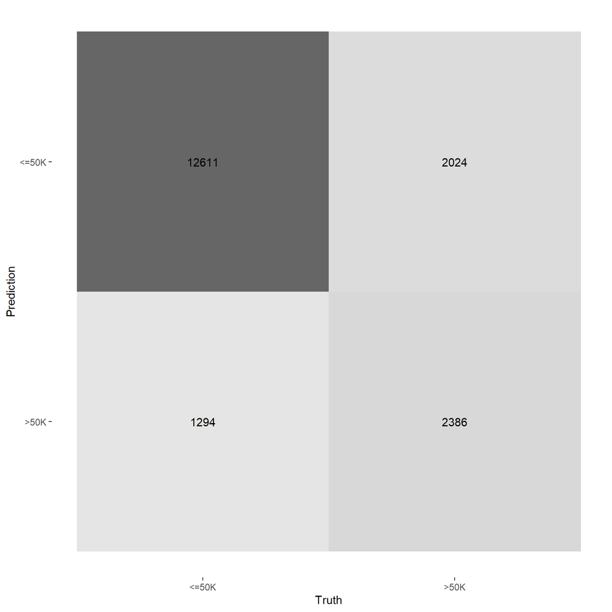

```r
knn_pred <-
  knn_res |>
  collect_predictions()


knn_pred |>
  conf_mat(over_50k, .pred_class) |>
  autoplot(type = "heatmap")
```

```r
# Matriz de confusión: etiqueta real vs etiqueta predicha
knn_pred
```

```
# A tibble: 18,315 × 8
   id      id2   .pred_class  .row .pred_<=5…¹ .pred…² over_…³ .config
   <chr>   <chr> <fct>       <int>       <dbl>   <dbl> <fct>   <chr>
 1 Repeat1 Fold1 <=50K           1       1      0      <=50K   Prepro…
 2 Repeat1 Fold1 <=50K           4       0.667  0.333  <=50K   Prepro…
 3 Repeat1 Fold1 <=50K          12       1      0      <=50K   Prepro…
 4 Repeat1 Fold1 <=50K          16       1      0      <=50K   Prepro…
 5 Repeat1 Fold1 <=50K          18       0.872  0.128  <=50K   Prepro…
 6 Repeat1 Fold1 <=50K          19       0.977  0.0232 <=50K   Prepro…
 7 Repeat1 Fold1 <=50K          23       0.781  0.219  <=50K   Prepro…
 8 Repeat1 Fold1 <=50K          32       0.605  0.395  <=50K   Prepro…
 9 Repeat1 Fold1 <=50K          38       1      0      <=50K   Prepro…
10 Repeat1 Fold1 <=50K          39       0.933  0.0668 <=50K   Prepro…
# … with 18,305 more rows, and abbreviated variable names
#   ¹`.pred_<=50K`, ²`.pred_>50K`, ³over_50k
```

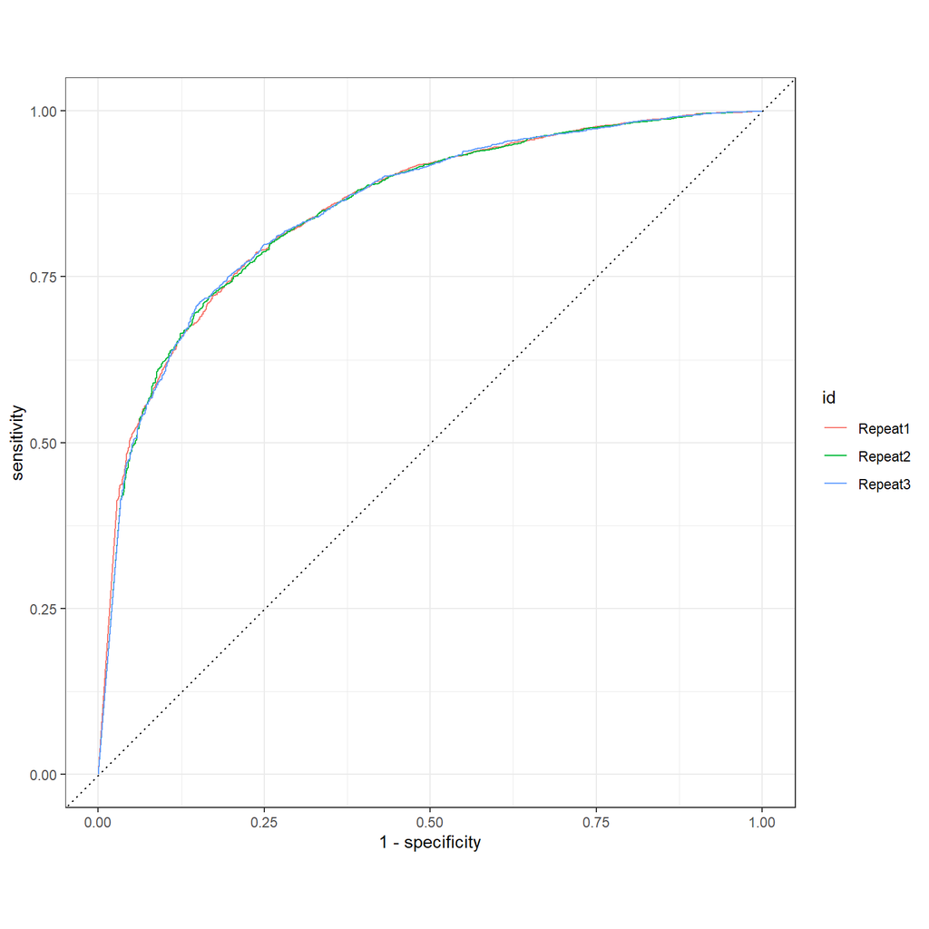

```r
# Matriz de confusión: etiqueta real vs etiqueta predicha
knn_pred |>
  group_by(id) |> # id contains our folds
  roc_curve(over_50k, `.pred_<=50K`) |>
  autoplot()
```

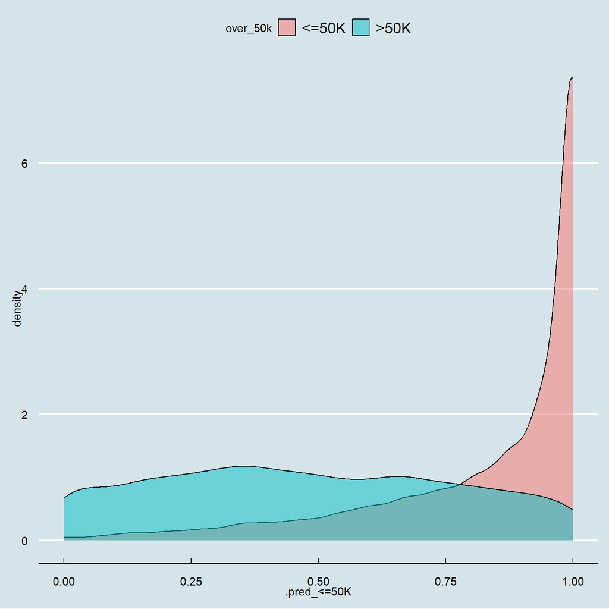

```r
knn_pred |>
  ggplot() +
  geom_density(aes(x = `.pred_<=50K`,
                   fill = over_50k),
               alpha = 0.5) +
  theme_economist()
```

# Fase 4 CART: modelo y flujo

```r
# Modelo
cart_model <- decision_tree(mode = "classification", tree_depth = 7,
                min_n = 0.025 * nrow(test_data),
                cost_complexity = 0.1) |> set_engine("rpart")

# Flujo de trabajo
cart_wflow_adultos <-
  workflow() |>
  add_recipe(cart_rec_adultos) |>
  add_model(cart_model)

cart_res <-
  cart_wflow_adultos |>
  fit_resamples(
    resamples = cv_folds,
    metrics = metric_set(recall, precision, accuracy,roc_auc, sens),
    control = control_resamples(save_pred = TRUE)
    )

cart_res |> collect_metrics(summarize = TRUE)
```

```
# A tibble: 5 × 6
  .metric   .estimator  mean     n std_err .config
  <chr>     <chr>      <dbl> <int>   <dbl> <chr>
1 accuracy  binary     0.805    15 0.00697 Preprocessor1_Model1
2 precision binary     0.867    15 0.00592 Preprocessor1_Model1
3 recall    binary     0.881    15 0.0159  Preprocessor1_Model1
4 roc_auc   binary     0.805    15 0.00484 Preprocessor1_Model1
5 sens      binary     0.881    15 0.0159  Preprocessor1_Model1
```

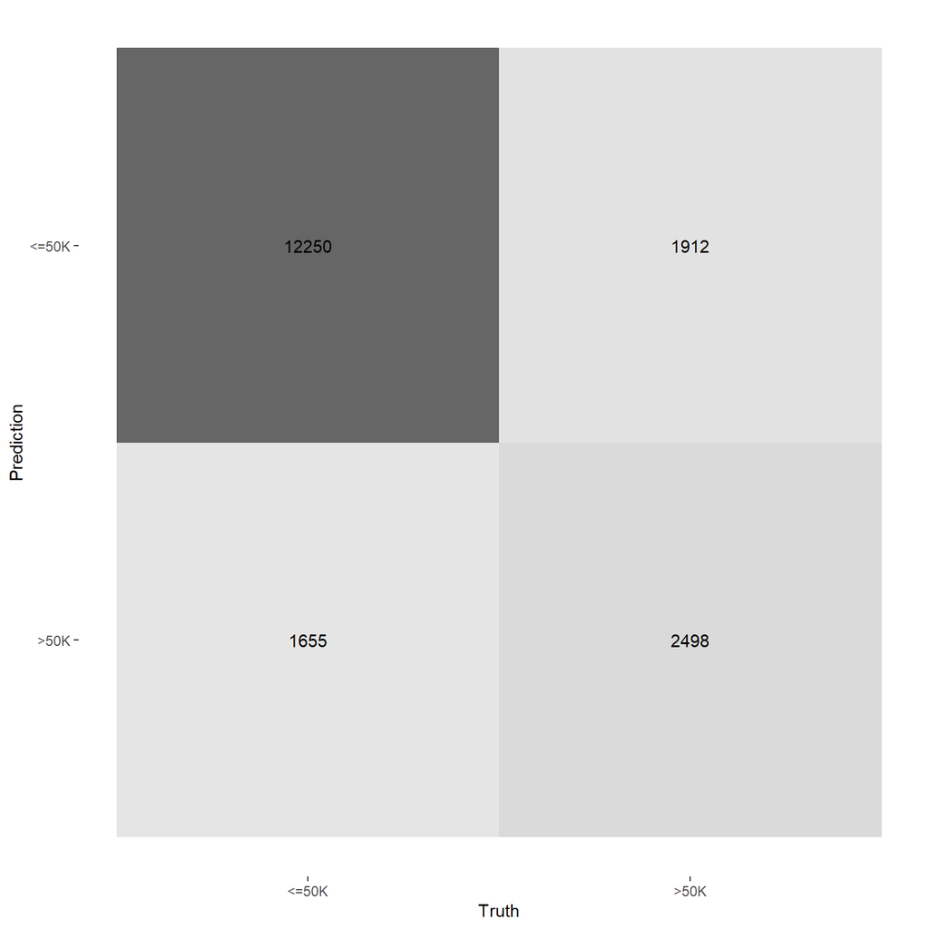

```r
cart_pred <-
  cart_res |>
  collect_predictions()


cart_pred |>
  conf_mat(over_50k, .pred_class) |>
  autoplot(type = "heatmap")
```

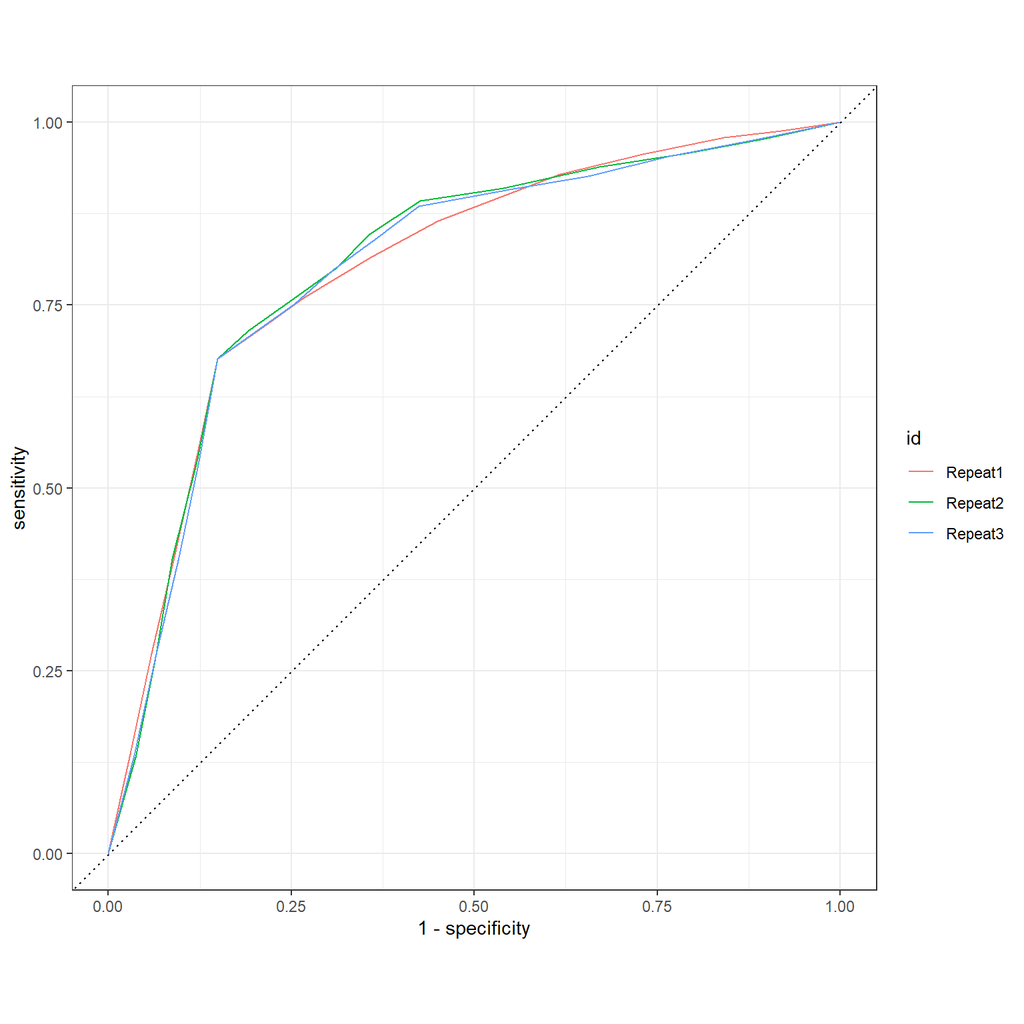

```r
# Matriz de confusión: etiqueta real vs etiqueta predicha
cart_pred |>
  group_by(id) |> # id contains our folds
  roc_curve(over_50k, `.pred_<=50K`) |>
  autoplot()
```

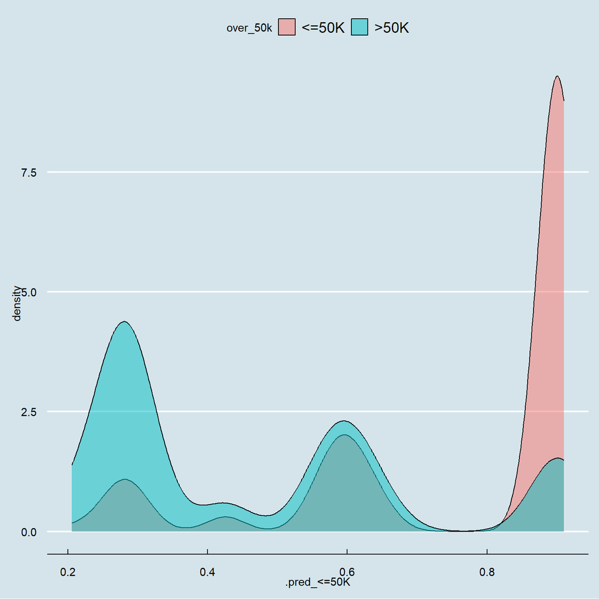

```r
cart_pred |>
  ggplot() +
  geom_density(aes(x = `.pred_<=50K`,
                   fill = over_50k),
               alpha = 0.5) +
  theme_economist()
```

## Visualizar el árbol

También podemos visualizar fácilmente los árboles generados con CART (Gini, del paquete `{rpart}`): primero con `extract_fit_engine()` extraemos las rutas del árbol, y después con `rpart.plot(roundint = FALSE, extra = 4)` le indicamos que no redondee valores a enteros y de los modelos de visualización elegimos `extra = 4` (prueba con varios para ver las diferencias). Para visualizar árboles `C5.0` ver documentación en https://topepo.github.io/C5.0/reference/plot.C5.0.html

```r
library("rpart.plot")
# Aplicamo flujo

# Calculamos probabilidades

cart_best_model <-
  cart_res |> select_best("roc_auc")

final_cart <-
  cart_wflow_adultos |>
  finalize_workflow(cart_best_model)

adultos_knn_fit <-
  final_cart |>
  last_fit(adultos_split)

# Calculamos métricas en test (las indicadas)
adultos_knn_fit |> collect_metrics()
```

```
# A tibble: 2 × 4
  .metric  .estimator .estimate .config
  <chr>    <chr>          <dbl> <chr>
1 accuracy binary         0.813 Preprocessor1_Model1
2 roc_auc  binary         0.805 Preprocessor1_Model1
```

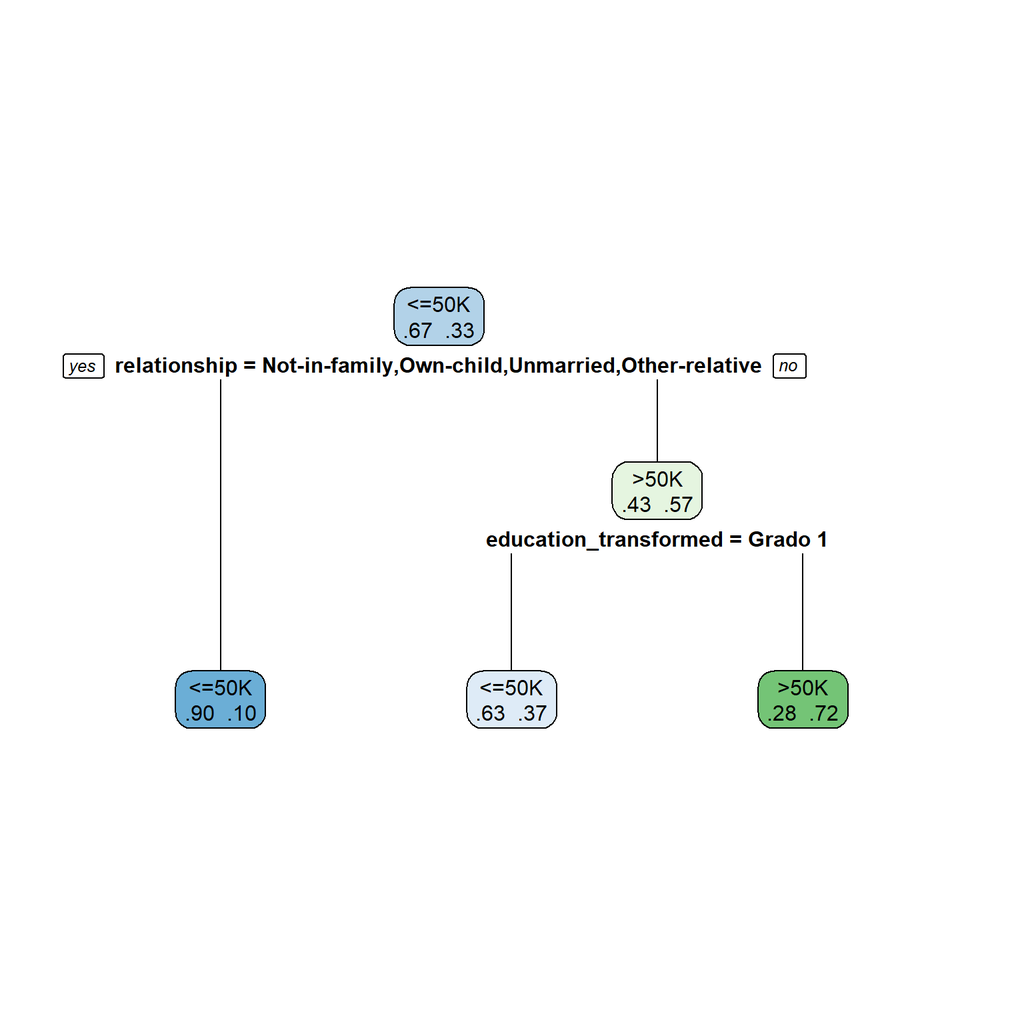

```r
adultos_knn_fit |>
 extract_fit_engine() |>
  rpart.plot(roundint = FALSE, extra = 4)
```

# Fase 4 Random Forest: modelo y flujo

```r
library(ranger)


# Modelo
rf_spec <-
  rand_forest() |>
  set_engine("ranger", importance = "impurity") |>
  set_mode("classification")


# Flujo de trabajo
rf_wflow <-
 workflow() |>
 add_recipe(rf_rec_adultos) |>
 add_model(rf_spec)

rf_res <-
  rf_wflow |>
  fit_resamples(
    resamples = cv_folds,
    metrics = metric_set(recall, precision, accuracy,roc_auc, sens),
    control = control_resamples(save_pred = TRUE)
    )

rf_res |> collect_metrics(summarize = TRUE)
```

```
# A tibble: 5 × 6
  .metric   .estimator  mean     n std_err .config
  <chr>     <chr>      <dbl> <int>   <dbl> <chr>
1 accuracy  binary     0.811    15 0.00214 Preprocessor1_Model1
2 precision binary     0.916    15 0.00241 Preprocessor1_Model1
3 recall    binary     0.828    15 0.00280 Preprocessor1_Model1
4 roc_auc   binary     0.887    15 0.00247 Preprocessor1_Model1
5 sens      binary     0.828    15 0.00280 Preprocessor1_Model1
```

[figure not shown]

```r
rf_pred <-
  rf_res |>
  collect_predictions()


knn_pred |>
  conf_mat(over_50k, .pred_class) |>
  autoplot(type = "heatmap")
```

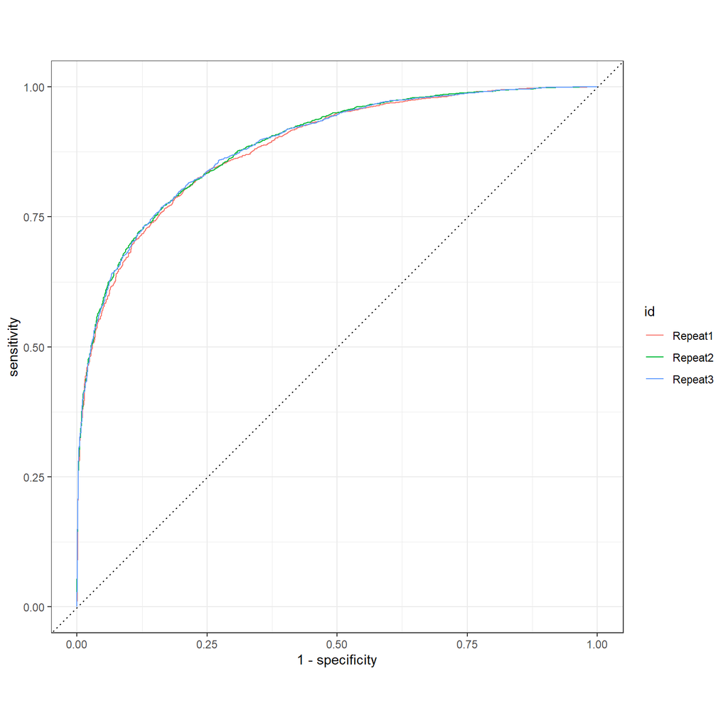

```r
# Matriz de confusión: etiqueta real vs etiqueta predicha
rf_pred |>
  group_by(id) |> # id contains our folds
  roc_curve(over_50k, `.pred_<=50K`) |>
  autoplot()
```

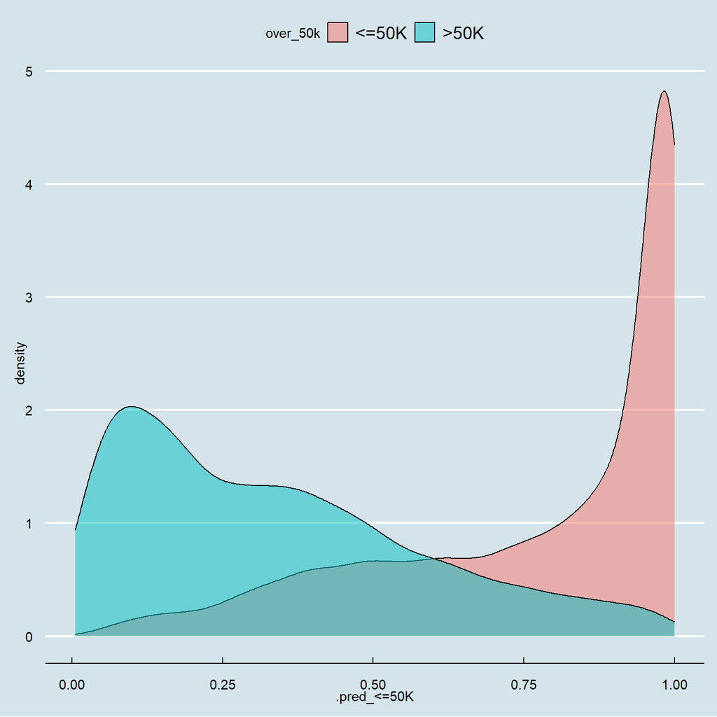

```r
rf_pred |>
  ggplot() +
  geom_density(aes(x = `.pred_<=50K`,
                   fill = over_50k),
               alpha = 0.5) +
  theme_economist()
```